# Employee Attrition

Blue

2022-11-22

### Read in data from S3 Bucket

```r
Sys.setenv("AWS_ACCESS_KEY_ID" = "AKIAVW4VHW4VPB7MHZWA",
           "AWS_SECRET_ACCESS_KEY" = "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",
           "AWS_DEFAULT_REGION" = "us-east-2")

aws.s3::bucketlist()
```

```
##              Bucket             CreationDate
## 1    smuddsproject2 2022-07-26T14:50:49.000Z
## 2         smuds6306 2021-11-16T13:35:36.000Z
## 3 smuds6306breakout 2021-11-17T00:23:04.000Z
```

```r
aws.s3::get_bucket("smuddsproject2")
```

```
## Bucket: smuddsproject2
##
## $Contents
## Key:            Case2PredictionsClassifyEXAMPLE.csv
## LastModified:   2022-07-18T19:01:53.000Z
## ETag:           "bd1de75effe9449f7d49a4de5116205a"
## Size (B):       3012
## Owner:          6a1a843f5cdc0cd887a7117c91d8bb3e0c9d31ba5db7441f7d01d6ade80cfac3
## Storage class:  STANDARD
##
## $Contents
## Key:            Case2PredictionsRegressEXAMPLE.csv
## LastModified:   2022-07-18T19:01:51.000Z
## ETag:           "a0f1f01c30e2cd00488822ad3c9aa6fe"
## Size (B):       3187
## Owner:          6a1a843f5cdc0cd887a7117c91d8bb3e0c9d31ba5db7441f7d01d6ade80cfac3
## Storage class:  STANDARD
##
## $Contents
## Key:            CaseStudy2-data.csv
## LastModified:   2022-07-18T19:00:38.000Z
## ETag:           "d68dd080517407fb3a4f05d91fed27d7"
## Size (B):       138428
## Owner:          6a1a843f5cdc0cd887a7117c91d8bb3e0c9d31ba5db7441f7d01d6ade80cfac3
## Storage class:  STANDARD
##
## $Contents
## Key:            CaseStudy2CompSet No Attrition.csv
## LastModified:   2022-07-18T19:01:55.000Z
## ETag:           "6c9d92b8a6fc5fd805ff0a5d4dfddde0"
## Size (B):       47686
## Owner:          6a1a843f5cdc0cd887a7117c91d8bb3e0c9d31ba5db7441f7d01d6ade80cfac3
## Storage class:  STANDARD
##
## $Contents
## Key:            CaseStudy2CompSet No Salary.xlsx
## LastModified:   2022-07-18T19:01:56.000Z
## ETag:           "bdcb211847739638a631f828a3278339"
## Size (B):       56381
## Owner:          6a1a843f5cdc0cd887a7117c91d8bb3e0c9d31ba5db7441f7d01d6ade80cfac3
## Storage class:  STANDARD
```

```r
# Full Training Set
initial_salary = s3read_using(FUN = read.csv,
                    bucket = "smuddsproject2",
                    object = "CaseStudy2-data.csv")
# First Competition Test Set with No Attrition Values
no_attrition = s3read_using(FUN = read.csv,
                    bucket = "smuddsproject2",
                    object = "CaseStudy2CompSet No Attrition.csv")
# Second Competition Test Set with No Salary Values
no_salary = s3read_using(FUN = read_xlsx,
                    bucket = "smuddsproject2",
                    object = "CaseStudy2CompSet No Salary.xlsx")

head(initial_salary)
```

```
##   ID Age Attrition    BusinessTravel DailyRate             Department
## 1  1  32        No     Travel_Rarely       117                  Sales
## 2  2  40        No     Travel_Rarely      1308 Research & Development
## 3  3  35        No Travel_Frequently       200 Research & Development
## 4  4  32        No     Travel_Rarely       801                  Sales
## 5  5  24        No Travel_Frequently       567 Research & Development
## 6  6  27        No Travel_Frequently       294 Research & Development
##   DistanceFromHome Education   EducationField EmployeeCount EmployeeNumber
## 1               13         4    Life Sciences             1            859
## 2               14         3          Medical             1           1128
## 3               18         2    Life Sciences             1           1412
## 4                1         4        Marketing             1           2016
## 5                2         1 Technical Degree             1           1646
## 6               10         2    Life Sciences             1            733
##   EnvironmentSatisfaction Gender HourlyRate JobInvolvement JobLevel
```

[output cut: 41 more lines]

```r
View(initial_salary) # Looks like we have 870 observations with 36 total columns
skim(initial_salary) # Looking through the n_missing, we show that we don't have any missing values!
```

Data summary

| Name | initial_salary |
| --- | --- |
| Number of rows | 870 |
| Number of columns | 36 |
| _______________________ |  |
| Column type frequency: |  |
| character | 9 |
| numeric | 27 |
| ________________________ |  |
| Group variables | None |

**Variable type: character**

| skim_variable | n_missing | complete_rate | min | max | empty | n_unique | whitespace |
| --- | --- | --- | --- | --- | --- | --- | --- |
| Attrition | 0 | 1 | 2 | 3 | 0 | 2 | 0 |
| BusinessTravel | 0 | 1 | 10 | 17 | 0 | 3 | 0 |
| Department | 0 | 1 | 5 | 22 | 0 | 3 | 0 |
| EducationField | 0 | 1 | 5 | 16 | 0 | 6 | 0 |
| Gender | 0 | 1 | 4 | 6 | 0 | 2 | 0 |
| JobRole | 0 | 1 | 7 | 25 | 0 | 9 | 0 |
| MaritalStatus | 0 | 1 | 6 | 8 | 0 | 3 | 0 |
| Over18 | 0 | 1 | 1 | 1 | 0 | 1 | 0 |
| OverTime | 0 | 1 | 2 | 3 | 0 | 2 | 0 |

**Variable type: numeric**

| skim_variable | n_missing | complete_rate | mean | sd | p0 | p25 | p50 | p75 | p100 | hist |
| --- | --- | --- | --- | --- | --- | --- | --- | --- | --- | --- |
| ID | 0 | 1 | 435.50 | 251.29 | 1 | 218.25 | 435.5 | 652.75 | 870 | ▇▇▇▇▇ |
| Age | 0 | 1 | 36.83 | 8.93 | 18 | 30.00 | 35.0 | 43.00 | 60 | ▂▇▇▃▂ |
| DailyRate | 0 | 1 | 815.23 | 401.12 | 103 | 472.50 | 817.5 | 1165.75 | 1499 | ▇▇▇▇▇ |
| DistanceFromHome | 0 | 1 | 9.34 | 8.14 | 1 | 2.00 | 7.0 | 14.00 | 29 | ▇▅▂▂▂ |
| Education | 0 | 1 | 2.90 | 1.02 | 1 | 2.00 | 3.0 | 4.00 | 5 | ▂▅▇▆▁ |
| EmployeeCount | 0 | 1 | 1.00 | 0.00 | 1 | 1.00 | 1.0 | 1.00 | 1 | ▁▁▇▁▁ |
| EmployeeNumber | 0 | 1 | 1029.83 | 604.79 | 1 | 477.25 | 1039.0 | 1561.50 | 2064 | ▇▇▇▇▇ |
| EnvironmentSatisfaction | 0 | 1 | 2.70 | 1.10 | 1 | 2.00 | 3.0 | 4.00 | 4 | ▅▆▁▇▇ |
| HourlyRate | 0 | 1 | 65.61 | 20.13 | 30 | 48.00 | 66.0 | 83.00 | 100 | ▇▇▆▇▇ |
| JobInvolvement | 0 | 1 | 2.72 | 0.70 | 1 | 2.00 | 3.0 | 3.00 | 4 | ▁▃▁▇▁ |
| JobLevel | 0 | 1 | 2.04 | 1.09 | 1 | 1.00 | 2.0 | 3.00 | 5 | ▇▇▃▂▁ |
| JobSatisfaction | 0 | 1 | 2.71 | 1.11 | 1 | 2.00 | 3.0 | 4.00 | 4 | ▅▅▁▇▇ |
| MonthlyIncome | 0 | 1 | 6390.26 | 4597.70 | 1081 | 2839.50 | 4945.5 | 8182.00 | 19999 | ▇▅▂▁▁ |
| MonthlyRate | 0 | 1 | 14325.62 | 7108.38 | 2094 | 8092.00 | 14074.5 | 20456.25 | 26997 | ▇▇▇▇▇ |
| NumCompaniesWorked | 0 | 1 | 2.73 | 2.52 | 0 | 1.00 | 2.0 | 4.00 | 9 | ▇▃▂▂▁ |
| PercentSalaryHike | 0 | 1 | 15.20 | 3.68 | 11 | 12.00 | 14.0 | 18.00 | 25 | ▇▅▃▂▁ |
| PerformanceRating | 0 | 1 | 3.15 | 0.36 | 3 | 3.00 | 3.0 | 3.00 | 4 | ▇▁▁▁▂ |
| RelationshipSatisfaction | 0 | 1 | 2.71 | 1.10 | 1 | 2.00 | 3.0 | 4.00 | 4 | ▅▅▁▇▇ |
| StandardHours | 0 | 1 | 80.00 | 0.00 | 80 | 80.00 | 80.0 | 80.00 | 80 | ▁▁▇▁▁ |
| StockOptionLevel | 0 | 1 | 0.78 | 0.86 | 0 | 0.00 | 1.0 | 1.00 | 3 | ▇▇▁▂▁ |
| TotalWorkingYears | 0 | 1 | 11.05 | 7.51 | 0 | 6.00 | 10.0 | 15.00 | 40 | ▇▇▂▁▁ |
| TrainingTimesLastYear | 0 | 1 | 2.83 | 1.27 | 0 | 2.00 | 3.0 | 3.00 | 6 | ▂▇▇▂▃ |
| WorkLifeBalance | 0 | 1 | 2.78 | 0.71 | 1 | 2.00 | 3.0 | 3.00 | 4 | ▁▃▁▇▂ |
| YearsAtCompany | 0 | 1 | 6.96 | 6.02 | 0 | 3.00 | 5.0 | 10.00 | 40 | ▇▃▁▁▁ |
| YearsInCurrentRole | 0 | 1 | 4.20 | 3.64 | 0 | 2.00 | 3.0 | 7.00 | 18 | ▇▃▂▁▁ |
| YearsSinceLastPromotion | 0 | 1 | 2.17 | 3.19 | 0 | 0.00 | 1.0 | 3.00 | 15 | ▇▁▁▁▁ |
| YearsWithCurrManager | 0 | 1 | 4.14 | 3.57 | 0 | 2.00 | 3.0 | 7.00 | 17 | ▇▂▅▁▁ |

```r
sal_clean <- initial_salary # Re-Assign the initial data set
```

We can see that we have 870 observations with 36 columns, 9 of which are Character variables and 27 Numeric variables. We can also see a few columns that have no variation, thus will not have any value in our analysis. These columns are Over18 (all Y), EmployeeCount (all 1), and StandardHours (all 80). We will remove these three columns for now. We can also remove ID and EmployeeNumber as they are just unique identifiers and are not quantitative variables.

### Removing Unessessary Columns

```r
sal_clean <- sal_clean %>% select(-c("Over18", "EmployeeCount", "StandardHours", "ID", "EmployeeNumber"))
sal_data <- sal_clean # Dataset for analysis

skim(sal_clean)
```

Data summary

| Name | sal_clean |
| --- | --- |
| Number of rows | 870 |
| Number of columns | 31 |
| _______________________ |  |
| Column type frequency: |  |
| character | 8 |
| numeric | 23 |
| ________________________ |  |
| Group variables | None |

**Variable type: character**

| skim_variable | n_missing | complete_rate | min | max | empty | n_unique | whitespace |
| --- | --- | --- | --- | --- | --- | --- | --- |
| Attrition | 0 | 1 | 2 | 3 | 0 | 2 | 0 |
| BusinessTravel | 0 | 1 | 10 | 17 | 0 | 3 | 0 |
| Department | 0 | 1 | 5 | 22 | 0 | 3 | 0 |
| EducationField | 0 | 1 | 5 | 16 | 0 | 6 | 0 |
| Gender | 0 | 1 | 4 | 6 | 0 | 2 | 0 |
| JobRole | 0 | 1 | 7 | 25 | 0 | 9 | 0 |
| MaritalStatus | 0 | 1 | 6 | 8 | 0 | 3 | 0 |
| OverTime | 0 | 1 | 2 | 3 | 0 | 2 | 0 |

**Variable type: numeric**

| skim_variable | n_missing | complete_rate | mean | sd | p0 | p25 | p50 | p75 | p100 | hist |
| --- | --- | --- | --- | --- | --- | --- | --- | --- | --- | --- |
| Age | 0 | 1 | 36.83 | 8.93 | 18 | 30.0 | 35.0 | 43.00 | 60 | ▂▇▇▃▂ |
| DailyRate | 0 | 1 | 815.23 | 401.12 | 103 | 472.5 | 817.5 | 1165.75 | 1499 | ▇▇▇▇▇ |
| DistanceFromHome | 0 | 1 | 9.34 | 8.14 | 1 | 2.0 | 7.0 | 14.00 | 29 | ▇▅▂▂▂ |
| Education | 0 | 1 | 2.90 | 1.02 | 1 | 2.0 | 3.0 | 4.00 | 5 | ▂▅▇▆▁ |
| EnvironmentSatisfaction | 0 | 1 | 2.70 | 1.10 | 1 | 2.0 | 3.0 | 4.00 | 4 | ▅▆▁▇▇ |
| HourlyRate | 0 | 1 | 65.61 | 20.13 | 30 | 48.0 | 66.0 | 83.00 | 100 | ▇▇▆▇▇ |
| JobInvolvement | 0 | 1 | 2.72 | 0.70 | 1 | 2.0 | 3.0 | 3.00 | 4 | ▁▃▁▇▁ |
| JobLevel | 0 | 1 | 2.04 | 1.09 | 1 | 1.0 | 2.0 | 3.00 | 5 | ▇▇▃▂▁ |
| JobSatisfaction | 0 | 1 | 2.71 | 1.11 | 1 | 2.0 | 3.0 | 4.00 | 4 | ▅▅▁▇▇ |
| MonthlyIncome | 0 | 1 | 6390.26 | 4597.70 | 1081 | 2839.5 | 4945.5 | 8182.00 | 19999 | ▇▅▂▁▁ |
| MonthlyRate | 0 | 1 | 14325.62 | 7108.38 | 2094 | 8092.0 | 14074.5 | 20456.25 | 26997 | ▇▇▇▇▇ |
| NumCompaniesWorked | 0 | 1 | 2.73 | 2.52 | 0 | 1.0 | 2.0 | 4.00 | 9 | ▇▃▂▂▁ |
| PercentSalaryHike | 0 | 1 | 15.20 | 3.68 | 11 | 12.0 | 14.0 | 18.00 | 25 | ▇▅▃▂▁ |
| PerformanceRating | 0 | 1 | 3.15 | 0.36 | 3 | 3.0 | 3.0 | 3.00 | 4 | ▇▁▁▁▂ |
| RelationshipSatisfaction | 0 | 1 | 2.71 | 1.10 | 1 | 2.0 | 3.0 | 4.00 | 4 | ▅▅▁▇▇ |
| StockOptionLevel | 0 | 1 | 0.78 | 0.86 | 0 | 0.0 | 1.0 | 1.00 | 3 | ▇▇▁▂▁ |
| TotalWorkingYears | 0 | 1 | 11.05 | 7.51 | 0 | 6.0 | 10.0 | 15.00 | 40 | ▇▇▂▁▁ |
| TrainingTimesLastYear | 0 | 1 | 2.83 | 1.27 | 0 | 2.0 | 3.0 | 3.00 | 6 | ▂▇▇▂▃ |
| WorkLifeBalance | 0 | 1 | 2.78 | 0.71 | 1 | 2.0 | 3.0 | 3.00 | 4 | ▁▃▁▇▂ |
| YearsAtCompany | 0 | 1 | 6.96 | 6.02 | 0 | 3.0 | 5.0 | 10.00 | 40 | ▇▃▁▁▁ |
| YearsInCurrentRole | 0 | 1 | 4.20 | 3.64 | 0 | 2.0 | 3.0 | 7.00 | 18 | ▇▃▂▁▁ |
| YearsSinceLastPromotion | 0 | 1 | 2.17 | 3.19 | 0 | 0.0 | 1.0 | 3.00 | 15 | ▇▁▁▁▁ |
| YearsWithCurrManager | 0 | 1 | 4.14 | 3.57 | 0 | 2.0 | 3.0 | 7.00 | 17 | ▇▂▅▁▁ |

My next step in data clean-up is to convert the character variables into factors.

### Process the data

```r
factor_cols <- c("Attrition","BusinessTravel","Department","EducationField","Gender","JobRole","MaritalStatus", "OverTime")
sal_clean[,factor_cols] <- lapply(sal_clean[,factor_cols], as.factor)
sal_data <- sal_clean # create a data set for analysis

skim(sal_clean)
```

Data summary

| Name | sal_clean |
| --- | --- |
| Number of rows | 870 |
| Number of columns | 31 |
| _______________________ |  |
| Column type frequency: |  |
| factor | 8 |
| numeric | 23 |
| ________________________ |  |
| Group variables | None |

**Variable type: factor**

| skim_variable | n_missing | complete_rate | ordered | n_unique | top_counts |
| --- | --- | --- | --- | --- | --- |
| Attrition | 0 | 1 | FALSE | 2 | No: 730, Yes: 140 |
| BusinessTravel | 0 | 1 | FALSE | 3 | Tra: 618, Tra: 158, Non: 94 |
| Department | 0 | 1 | FALSE | 3 | Res: 562, Sal: 273, Hum: 35 |
| EducationField | 0 | 1 | FALSE | 6 | Lif: 358, Med: 270, Mar: 100, Tec: 75 |
| Gender | 0 | 1 | FALSE | 2 | Mal: 516, Fem: 354 |
| JobRole | 0 | 1 | FALSE | 9 | Sal: 200, Res: 172, Lab: 153, Man: 87 |
| MaritalStatus | 0 | 1 | FALSE | 3 | Mar: 410, Sin: 269, Div: 191 |
| OverTime | 0 | 1 | FALSE | 2 | No: 618, Yes: 252 |

**Variable type: numeric**

| skim_variable | n_missing | complete_rate | mean | sd | p0 | p25 | p50 | p75 | p100 | hist |
| --- | --- | --- | --- | --- | --- | --- | --- | --- | --- | --- |
| Age | 0 | 1 | 36.83 | 8.93 | 18 | 30.0 | 35.0 | 43.00 | 60 | ▂▇▇▃▂ |
| DailyRate | 0 | 1 | 815.23 | 401.12 | 103 | 472.5 | 817.5 | 1165.75 | 1499 | ▇▇▇▇▇ |
| DistanceFromHome | 0 | 1 | 9.34 | 8.14 | 1 | 2.0 | 7.0 | 14.00 | 29 | ▇▅▂▂▂ |
| Education | 0 | 1 | 2.90 | 1.02 | 1 | 2.0 | 3.0 | 4.00 | 5 | ▂▅▇▆▁ |
| EnvironmentSatisfaction | 0 | 1 | 2.70 | 1.10 | 1 | 2.0 | 3.0 | 4.00 | 4 | ▅▆▁▇▇ |
| HourlyRate | 0 | 1 | 65.61 | 20.13 | 30 | 48.0 | 66.0 | 83.00 | 100 | ▇▇▆▇▇ |
| JobInvolvement | 0 | 1 | 2.72 | 0.70 | 1 | 2.0 | 3.0 | 3.00 | 4 | ▁▃▁▇▁ |
| JobLevel | 0 | 1 | 2.04 | 1.09 | 1 | 1.0 | 2.0 | 3.00 | 5 | ▇▇▃▂▁ |
| JobSatisfaction | 0 | 1 | 2.71 | 1.11 | 1 | 2.0 | 3.0 | 4.00 | 4 | ▅▅▁▇▇ |
| MonthlyIncome | 0 | 1 | 6390.26 | 4597.70 | 1081 | 2839.5 | 4945.5 | 8182.00 | 19999 | ▇▅▂▁▁ |
| MonthlyRate | 0 | 1 | 14325.62 | 7108.38 | 2094 | 8092.0 | 14074.5 | 20456.25 | 26997 | ▇▇▇▇▇ |
| NumCompaniesWorked | 0 | 1 | 2.73 | 2.52 | 0 | 1.0 | 2.0 | 4.00 | 9 | ▇▃▂▂▁ |
| PercentSalaryHike | 0 | 1 | 15.20 | 3.68 | 11 | 12.0 | 14.0 | 18.00 | 25 | ▇▅▃▂▁ |
| PerformanceRating | 0 | 1 | 3.15 | 0.36 | 3 | 3.0 | 3.0 | 3.00 | 4 | ▇▁▁▁▂ |
| RelationshipSatisfaction | 0 | 1 | 2.71 | 1.10 | 1 | 2.0 | 3.0 | 4.00 | 4 | ▅▅▁▇▇ |
| StockOptionLevel | 0 | 1 | 0.78 | 0.86 | 0 | 0.0 | 1.0 | 1.00 | 3 | ▇▇▁▂▁ |
| TotalWorkingYears | 0 | 1 | 11.05 | 7.51 | 0 | 6.0 | 10.0 | 15.00 | 40 | ▇▇▂▁▁ |
| TrainingTimesLastYear | 0 | 1 | 2.83 | 1.27 | 0 | 2.0 | 3.0 | 3.00 | 6 | ▂▇▇▂▃ |
| WorkLifeBalance | 0 | 1 | 2.78 | 0.71 | 1 | 2.0 | 3.0 | 3.00 | 4 | ▁▃▁▇▂ |
| YearsAtCompany | 0 | 1 | 6.96 | 6.02 | 0 | 3.0 | 5.0 | 10.00 | 40 | ▇▃▁▁▁ |
| YearsInCurrentRole | 0 | 1 | 4.20 | 3.64 | 0 | 2.0 | 3.0 | 7.00 | 18 | ▇▃▂▁▁ |
| YearsSinceLastPromotion | 0 | 1 | 2.17 | 3.19 | 0 | 0.0 | 1.0 | 3.00 | 15 | ▇▁▁▁▁ |
| YearsWithCurrManager | 0 | 1 | 4.14 | 3.57 | 0 | 2.0 | 3.0 | 7.00 | 17 | ▇▂▅▁▁ |

Now we have a new dataset called “sal_data” that has 8 factors and 23 numeric variables that we can use for our KNN, NB, and LM analysis later on.

## EDA - Deep analysis on Attrition and Monthly Income vs each variable

My first step in going into my EDA is to create an EDA dataset that I can use for visual analysis. Factors tend to work best as they are split up into different levels and you can visualize the data easier this way. A new dataset will allow me to do this without affecting my analysis dataset. I will call this new set “sal_eda”

```r
sal_eda <- sal_clean

factor_cols2 <- c("JobInvolvement", "JobSatisfaction", "PerformanceRating", "RelationshipSatisfaction", "WorkLifeBalance","Education", "EnvironmentSatisfaction", "JobLevel", "NumCompaniesWorked", "PercentSalaryHike",  "StockOptionLevel", "TotalWorkingYears", "TrainingTimesLastYear", "YearsAtCompany", "YearsInCurrentRole",  "YearsSinceLastPromotion", "YearsWithCurrManager")

sal_eda[,factor_cols2] <- lapply(sal_eda[,factor_cols2], as.factor)

skim(sal_eda)
```

Data summary

| Name | sal_eda |
| --- | --- |
| Number of rows | 870 |
| Number of columns | 31 |
| _______________________ |  |
| Column type frequency: |  |
| factor | 25 |
| numeric | 6 |
| ________________________ |  |
| Group variables | None |

**Variable type: factor**

| skim_variable | n_missing | complete_rate | ordered | n_unique | top_counts |
| --- | --- | --- | --- | --- | --- |
| Attrition | 0 | 1 | FALSE | 2 | No: 730, Yes: 140 |
| BusinessTravel | 0 | 1 | FALSE | 3 | Tra: 618, Tra: 158, Non: 94 |
| Department | 0 | 1 | FALSE | 3 | Res: 562, Sal: 273, Hum: 35 |
| Education | 0 | 1 | FALSE | 5 | 3: 324, 4: 240, 2: 182, 1: 98 |
| EducationField | 0 | 1 | FALSE | 6 | Lif: 358, Med: 270, Mar: 100, Tec: 75 |
| EnvironmentSatisfaction | 0 | 1 | FALSE | 4 | 4: 262, 3: 258, 2: 178, 1: 172 |
| Gender | 0 | 1 | FALSE | 2 | Mal: 516, Fem: 354 |
| JobInvolvement | 0 | 1 | FALSE | 4 | 3: 514, 2: 228, 4: 81, 1: 47 |
| JobLevel | 0 | 1 | FALSE | 5 | 1: 329, 2: 312, 3: 132, 4: 60 |
| JobRole | 0 | 1 | FALSE | 9 | Sal: 200, Res: 172, Lab: 153, Man: 87 |
| JobSatisfaction | 0 | 1 | FALSE | 4 | 4: 271, 3: 254, 1: 179, 2: 166 |
| MaritalStatus | 0 | 1 | FALSE | 3 | Mar: 410, Sin: 269, Div: 191 |
| NumCompaniesWorked | 0 | 1 | FALSE | 10 | 1: 320, 0: 111, 3: 91, 4: 85 |
| OverTime | 0 | 1 | FALSE | 2 | No: 618, Yes: 252 |
| PercentSalaryHike | 0 | 1 | FALSE | 15 | 11: 126, 13: 123, 14: 120, 12: 119 |
| PerformanceRating | 0 | 1 | FALSE | 2 | 3: 738, 4: 132 |
| RelationshipSatisfaction | 0 | 1 | FALSE | 4 | 4: 264, 3: 261, 1: 174, 2: 171 |
| StockOptionLevel | 0 | 1 | FALSE | 4 | 0: 379, 1: 355, 2: 81, 3: 55 |
| TotalWorkingYears | 0 | 1 | FALSE | 39 | 10: 132, 6: 72, 8: 61, 9: 58 |
| TrainingTimesLastYear | 0 | 1 | FALSE | 7 | 2: 309, 3: 308, 5: 75, 4: 73 |
| WorkLifeBalance | 0 | 1 | FALSE | 4 | 3: 532, 2: 192, 4: 98, 1: 48 |
| YearsAtCompany | 0 | 1 | FALSE | 32 | 1: 107, 5: 105, 3: 85, 2: 77 |
| YearsInCurrentRole | 0 | 1 | FALSE | 19 | 2: 223, 0: 151, 7: 136, 3: 68 |
| YearsSinceLastPromotion | 0 | 1 | FALSE | 16 | 0: 342, 1: 214, 2: 94, 7: 41 |
| YearsWithCurrManager | 0 | 1 | FALSE | 17 | 2: 202, 0: 166, 7: 131, 3: 76 |

**Variable type: numeric**

| skim_variable | n_missing | complete_rate | mean | sd | p0 | p25 | p50 | p75 | p100 | hist |
| --- | --- | --- | --- | --- | --- | --- | --- | --- | --- | --- |
| Age | 0 | 1 | 36.83 | 8.93 | 18 | 30.0 | 35.0 | 43.00 | 60 | ▂▇▇▃▂ |
| DailyRate | 0 | 1 | 815.23 | 401.12 | 103 | 472.5 | 817.5 | 1165.75 | 1499 | ▇▇▇▇▇ |
| DistanceFromHome | 0 | 1 | 9.34 | 8.14 | 1 | 2.0 | 7.0 | 14.00 | 29 | ▇▅▂▂▂ |
| HourlyRate | 0 | 1 | 65.61 | 20.13 | 30 | 48.0 | 66.0 | 83.00 | 100 | ▇▇▆▇▇ |
| MonthlyIncome | 0 | 1 | 6390.26 | 4597.70 | 1081 | 2839.5 | 4945.5 | 8182.00 | 19999 | ▇▅▂▁▁ |
| MonthlyRate | 0 | 1 | 14325.62 | 7108.38 | 2094 | 8092.0 | 14074.5 | 20456.25 | 26997 | ▇▇▇▇▇ |

In this EDA we will look at how each variable in our dataset interacts with both Employee Attrition and Monthly Income.

First, lets take a look at our two variables a bit closer

### Employee Attrition

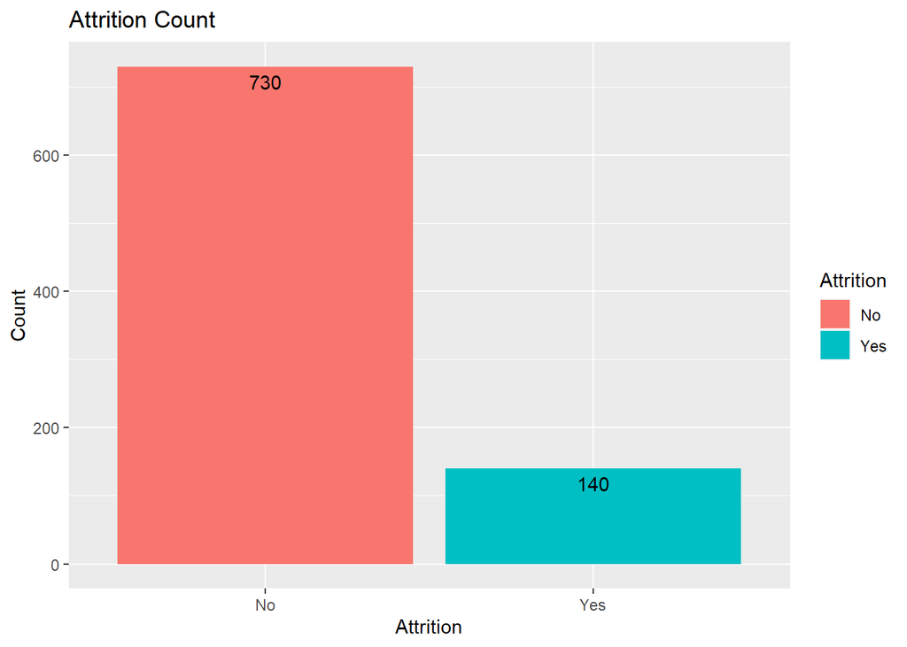

```r
sal_eda %>% ggplot(aes(x=Attrition,fill=Attrition)) +
  geom_bar()+
  geom_text(aes(label = after_stat(count)), stat = "count", vjust = 1.5, position = position_dodge(0.9) ,colour = "black")+
  xlab("Attrition")+ylab("Count") +
  ggtitle("Attrition Count")
```

We see that out of the 870 observed employees, 140 left. This is roughly a 16% Attrition Rate. There are also many more employees who have stayed vs those who have left, but we still want to explore why our attrition rate is so high. Typically, companies want to aim for attrition rates lower than 10%.

Lets move on to the second variable: Monthly Income

### Monthly Income

This plot displays the distribution of monthly income across all 870 employees

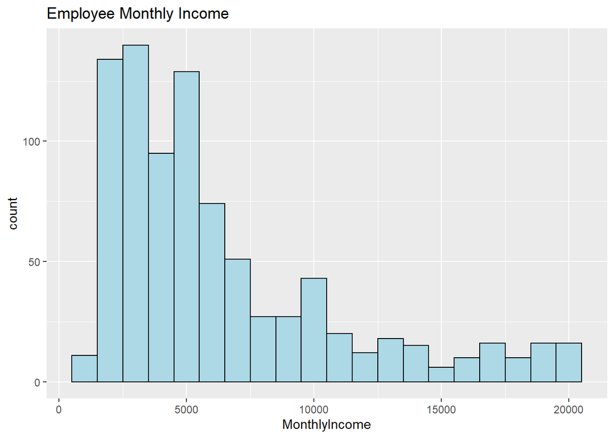

```r
sal_eda %>%
  ggplot(aes(x=MonthlyIncome))+
  geom_histogram(binwidth = 1000, color = "black", fill = "lightblue") +
  ggtitle("Employee Monthly Income")
```

Due to the wide spread of income (from 0-20,000), I want to group them into 5 groups: 0 - 3999, 4000 - 7999, 8000 - 11999, 12000 - 15999, and 16000 - <20000. This will allow me to look at different statistics between the various income classes.

```r
sal_eda$IncomeRange <- cut(sal_eda$MonthlyIncome, c(0,4000,8000,12000,16000,20000), labels = c("<4000", "4000 - 7999", "8000 - 11999", "12000 - 15999", "16000 - <20000"))
```

Lets see what our new column looks like

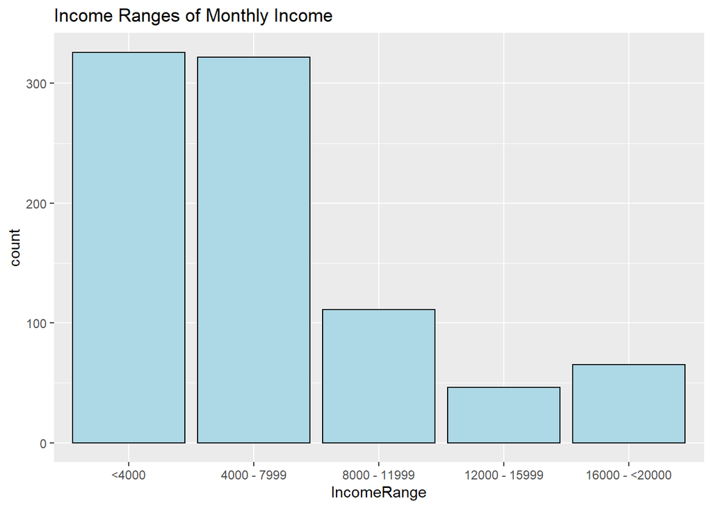

```r
sal_eda %>%
  ggplot(aes(IncomeRange)) +
  geom_bar(color = "black", fill = "lightblue") +
  ggtitle("Income Ranges of Monthly Income")
```

As we suspected, the majority of employees recorded make less than 8,000 per month.

Now lets take a look at the relationship between the two explanatory variables (Monthly Income and Attrition). I added a reference line at 16% to show the company attrition rate

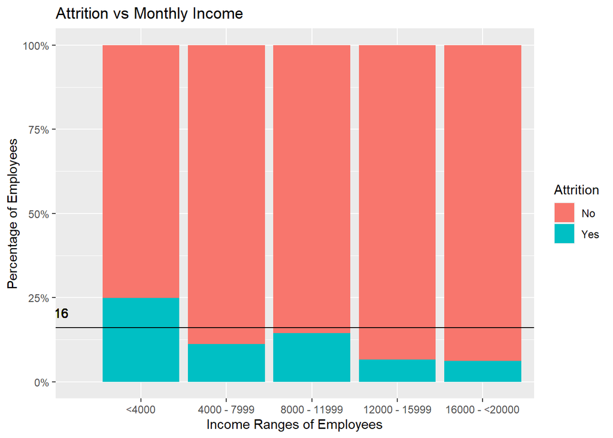

```r
h_line <- .16

sal_eda %>%
  ggplot(aes(x=IncomeRange,fill=Attrition))+
  geom_bar(position = "fill")+
  ggtitle("Attrition vs Monthly Income") +
  scale_y_continuous(labels = scales::percent) +
  geom_hline(aes(yintercept = h_line)) +
  geom_text(aes(0, h_line, label = h_line, vjust = - 1)) +
  xlab("Income Ranges of Employees") +
  ylab("Percentage of Employees")
```

This bar chart shows that employees making less than 4,000 per month are more likely to leave their job than any other group. The range between 8000 - 11,999 are close to the line as well

Lets dive into the HourlyRate, DailyRate, and MonthlyRate variables. I mainly will be checking to see if they have any correlation towards both Monthly Income and Attrition Rates.

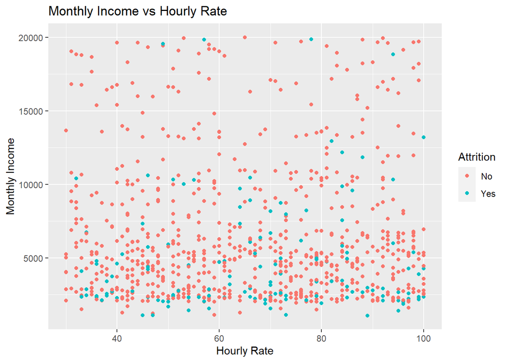

```r
sal_eda %>%
  ggplot(aes(x=HourlyRate,y= MonthlyIncome, color = Attrition)) +
  geom_point() +
  ggtitle("Monthly Income vs Hourly Rate") +
  xlab("Hourly Rate") +
  ylab("Monthly Income")
```

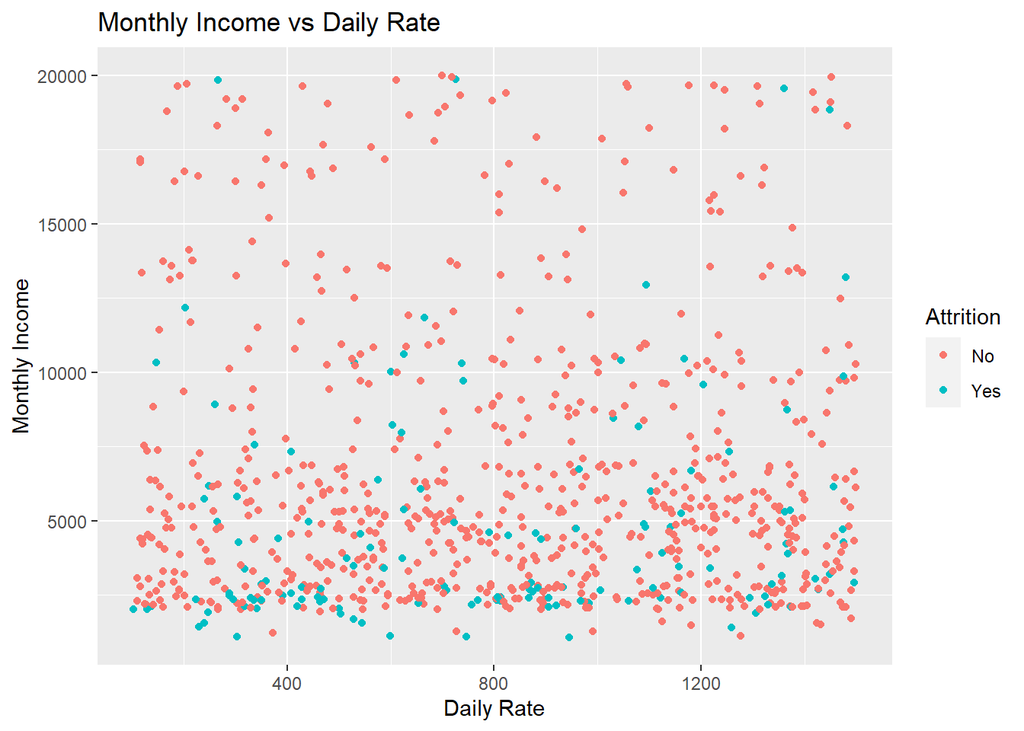

```r
sal_eda %>%
  ggplot(aes(x=DailyRate,y= MonthlyIncome, color = Attrition)) +
  geom_point() +
  ggtitle("Monthly Income vs Daily Rate") +
  xlab("Daily Rate") +
  ylab("Monthly Income")
```

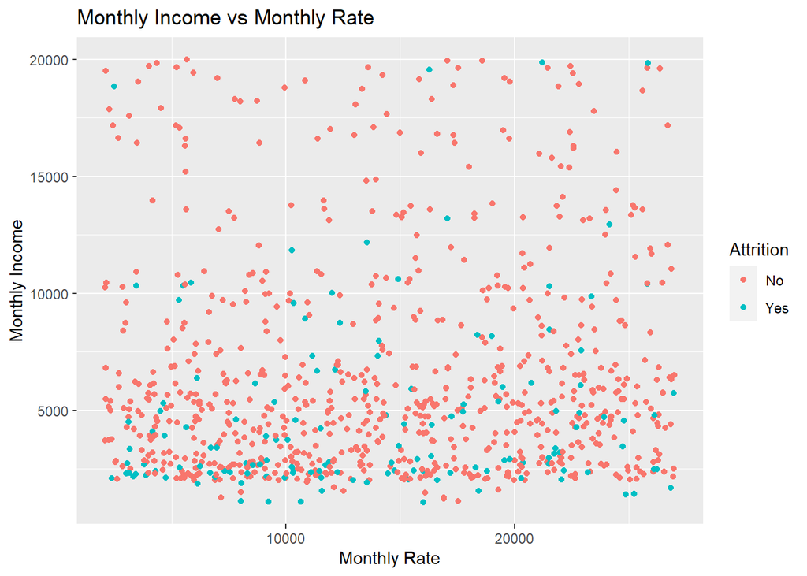

```r
sal_eda %>%
  ggplot(aes(x=MonthlyRate,y= MonthlyIncome, color = Attrition)) +
  geom_point() +
  ggtitle("Monthly Income vs Monthly Rate") +
  xlab("Monthly Rate") +
  ylab("Monthly Income")
```

There does not seem to be any kind of correlation between any of the three rates in association with Monthly Income nor with Attrition rate, but we can perform a better analysis before selecting the model.

Now lets take a look at each variable and any associations they might have with Monthly Income and Attrition Rate. I will be doing Box Plots and Bar Graphs to visualize these relationships (if any).

### Age

First lets take a look the Age range of all recorded employees

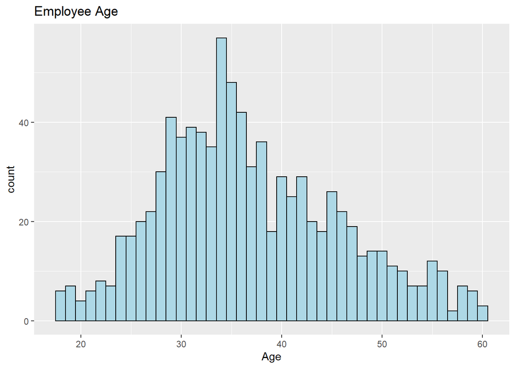

```r
sal_eda %>%
  ggplot(aes(x=Age))+
  geom_histogram(binwidth = 1, color = "black", fill = "lightblue") +
  ggtitle("Employee Age")
```

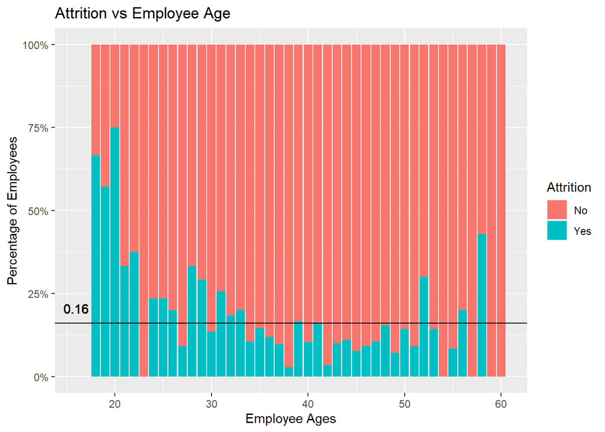

```r
sal_eda %>%
  ggplot(aes(x=Age,fill=Attrition))+
  geom_bar(position = "fill")+
  ggtitle("Attrition vs Employee Age") +
  scale_y_continuous(labels = scales::percent) +
  geom_hline(aes(yintercept = h_line)) +
  geom_text(aes(16, h_line, label = h_line, vjust = - 1)) +
  xlab("Employee Ages") +
  ylab("Percentage of Employees")
```

```r
range(sal_eda$Age)
```

```
## [1] 18 60
```

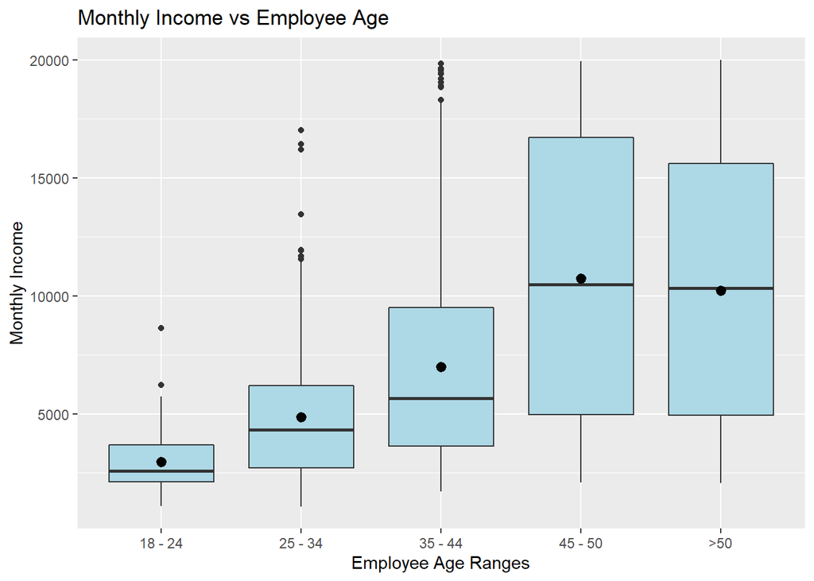

```r
sal_eda$AgeRange <- cut(sal_eda$Age, c(18,25,35,45,50,60), labels = c("18 - 24", "25 - 34", "35 - 44", "45 - 50", ">50"), include.lowest = T)

sal_eda %>%
  ggplot(aes(x=AgeRange,y= MonthlyIncome)) +
  geom_boxplot(fill = "lightblue") +
  stat_summary(fun=mean)  +
  ggtitle("Monthly Income vs Employee Age") +
  xlab("Employee Age Ranges") +
  ylab("Monthly Income")
```

The Age ranges with the highest income seem to be between 45 - >50.

### BusinessTravel

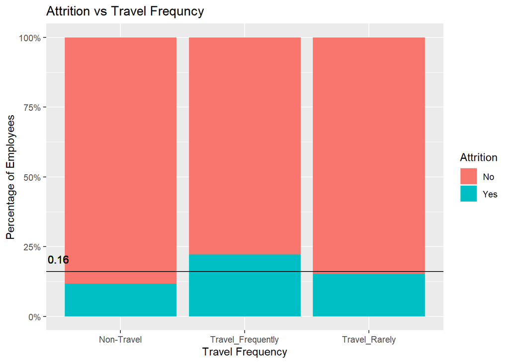

```r
sal_eda %>%
  ggplot(aes(x=BusinessTravel,fill=Attrition))+
  geom_bar(position = "fill")+
  ggtitle("Attrition vs Travel Frequncy") +
  scale_y_continuous(labels = scales::percent) +
  geom_hline(aes(yintercept = h_line)) +
  geom_text(aes(0.5, h_line, label = h_line, vjust = - 1)) +
  xlab("Travel Frequency") +
  ylab("Percentage of Employees")
```

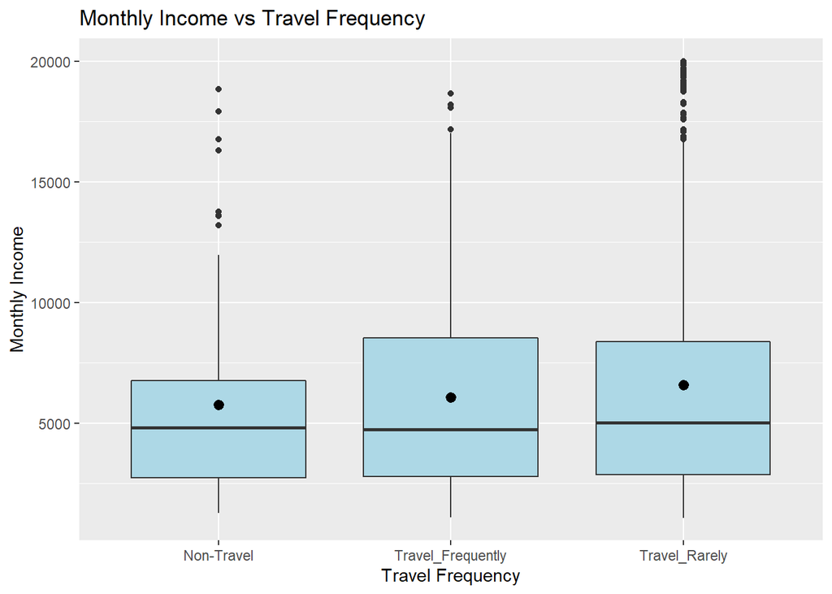

```r
sal_eda %>%
  ggplot(aes(x=BusinessTravel,y= MonthlyIncome)) +
  geom_boxplot(fill = "lightblue") +
  stat_summary(fun=mean)  +
  ggtitle("Monthly Income vs Travel Frequency") +
  xlab("Travel Frequency") +
  ylab("Monthly Income")
```

### Department

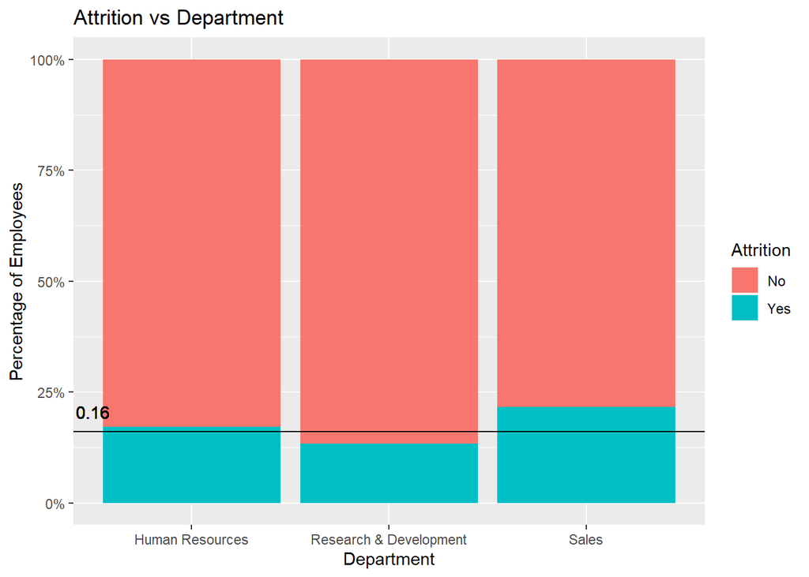

```r
sal_eda %>%
  ggplot(aes(x=Department,fill=Attrition))+
  geom_bar(position = "fill")+
  ggtitle("Attrition vs Department") +
  scale_y_continuous(labels = scales::percent) +
  geom_hline(aes(yintercept = h_line)) +
  geom_text(aes(0.5, h_line, label = h_line, vjust = - 1)) +
  xlab("Department") +
  ylab("Percentage of Employees")
```

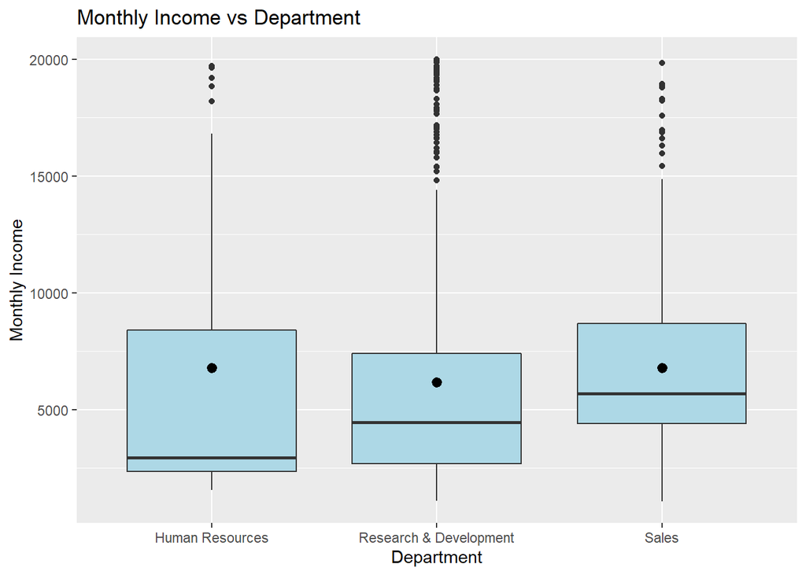

```r
sal_eda %>%
  ggplot(aes(x=Department,y= MonthlyIncome)) +
  geom_boxplot(fill = "lightblue") +
  stat_summary(fun=mean)  +
  ggtitle("Monthly Income vs Department") +
  xlab("Department") +
  ylab("Monthly Income")
```

Sales looks to have the highest attrition rate followed by Human Resources. Human Resources also looks to have the highest variance of salary but all three departments look to have around the same mean monthly income.

### Distance from Home

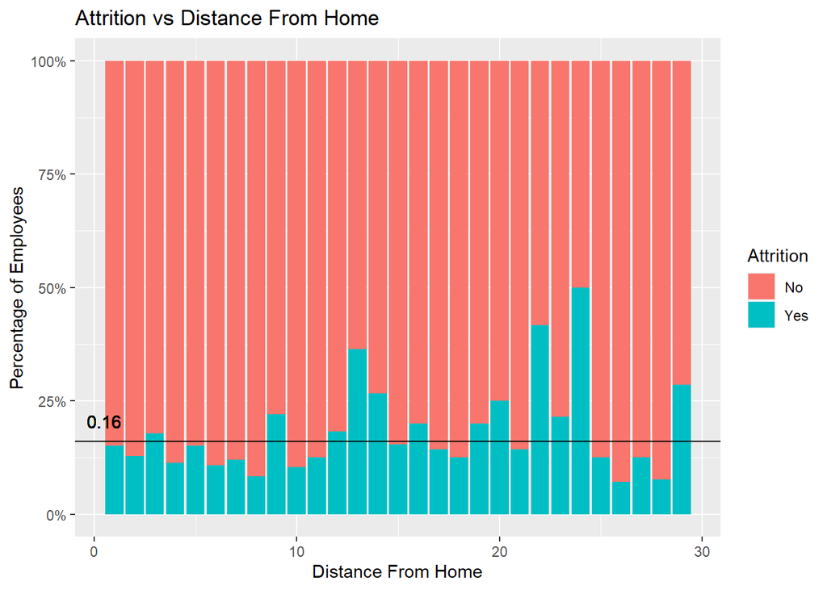

```r
sal_eda %>%
  ggplot(aes(x=DistanceFromHome,fill=Attrition))+
  geom_bar(position = "fill")+
  ggtitle("Attrition vs Distance From Home") +
  scale_y_continuous(labels = scales::percent) +
  geom_hline(aes(yintercept = h_line)) +
  geom_text(aes(0.5, h_line, label = h_line, vjust = - 1)) +
  xlab("Distance From Home") +
  ylab("Percentage of Employees")
```

There does not seem to be any significant relationship between how far an employees commute is vs their attrition rate

### Education

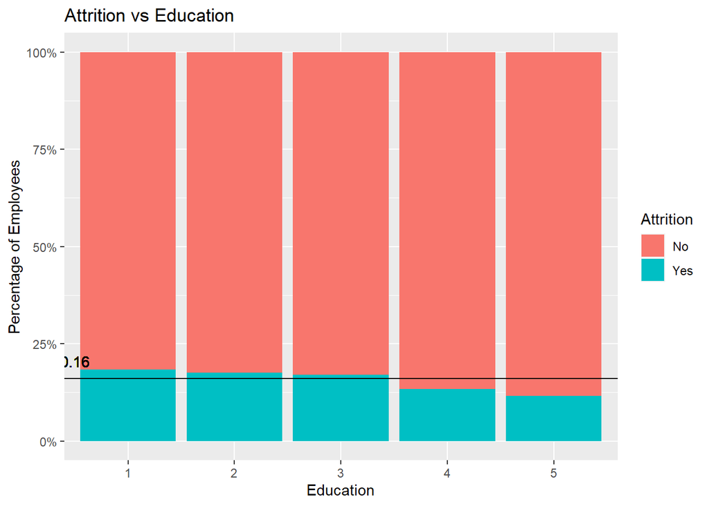

```r
sal_eda %>%
  ggplot(aes(x=Education,fill=Attrition))+
  geom_bar(position = "fill")+
  ggtitle("Attrition vs Education") +
  scale_y_continuous(labels = scales::percent) +
  geom_hline(aes(yintercept = h_line)) +
  geom_text(aes(0.5, h_line, label = h_line, vjust = - 1)) +
  xlab("Education") +
  ylab("Percentage of Employees")
```

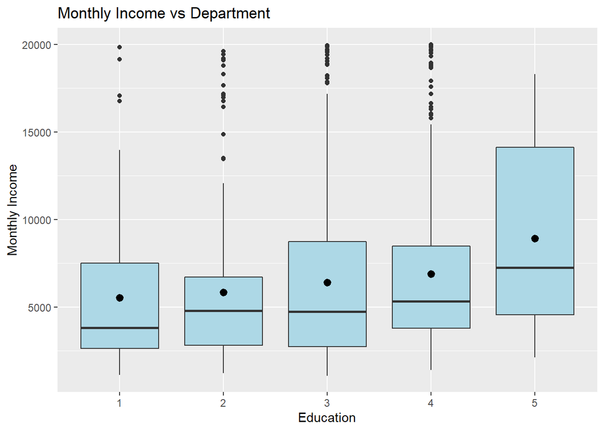

```r
sal_eda %>%
  ggplot(aes(x=Education,y= MonthlyIncome)) +
  geom_boxplot(fill = "lightblue") +
  stat_summary(fun=mean)  +
  ggtitle("Monthly Income vs Department") +
  xlab("Education") +
  ylab("Monthly Income")
```

Education levels lower than 4 look to have the higher levels of attrition and an education level of 5 is associated with an overall higher salary.

### Education Field

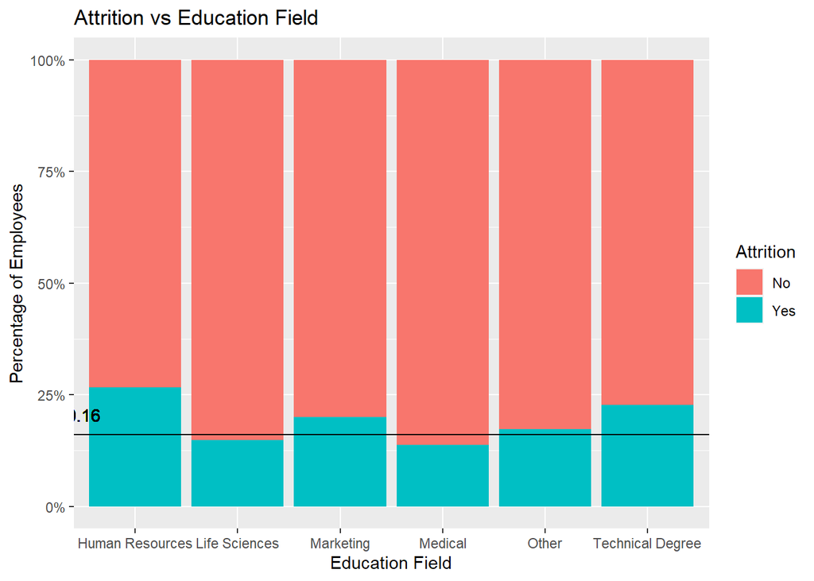

```r
sal_eda %>%
  ggplot(aes(x=EducationField,fill=Attrition))+
  geom_bar(position = "fill")+
  ggtitle("Attrition vs Education Field") +
  scale_y_continuous(labels = scales::percent) +
  geom_hline(aes(yintercept = h_line)) +
  geom_text(aes(0.5, h_line, label = h_line, vjust = - 1)) +
  xlab("Education Field") +
  ylab("Percentage of Employees")
```

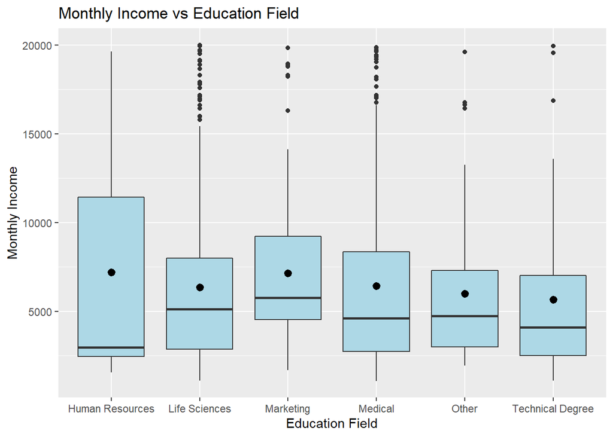

```r
sal_eda %>%
  ggplot(aes(x=EducationField,y= MonthlyIncome)) +
  geom_boxplot(fill = "lightblue") +
  stat_summary(fun=mean)  +
  ggtitle("Monthly Income vs Education Field") +
  xlab("Education Field") +
  ylab("Monthly Income")
```

Much like the department, employees who studied Human Resources have the highest variance of salaries compared to the other fields. They also have a higher level of attrition along with Marketing and those with technical degrees.

### Environment Satisfaction

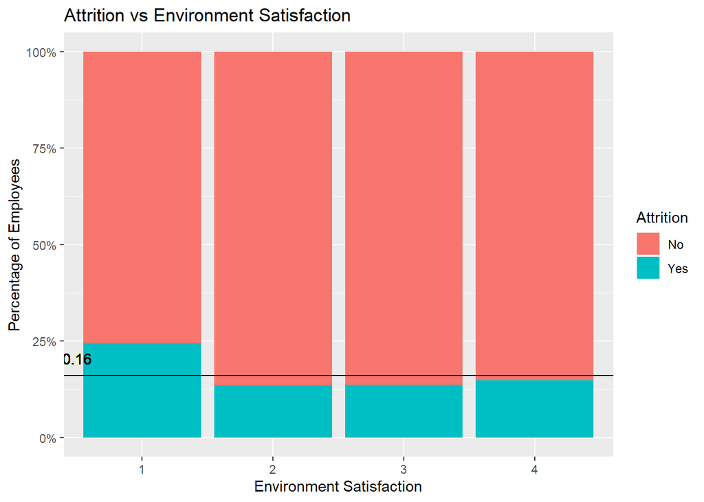

```r
sal_eda %>%
  ggplot(aes(x=EnvironmentSatisfaction,fill=Attrition))+
  geom_bar(position = "fill")+
  ggtitle("Attrition vs Environment Satisfaction") +
  scale_y_continuous(labels = scales::percent) +
  geom_hline(aes(yintercept = h_line)) +
  geom_text(aes(0.5, h_line, label = h_line, vjust = - 1)) +
  xlab("Environment Satisfaction") +
  ylab("Percentage of Employees")
```

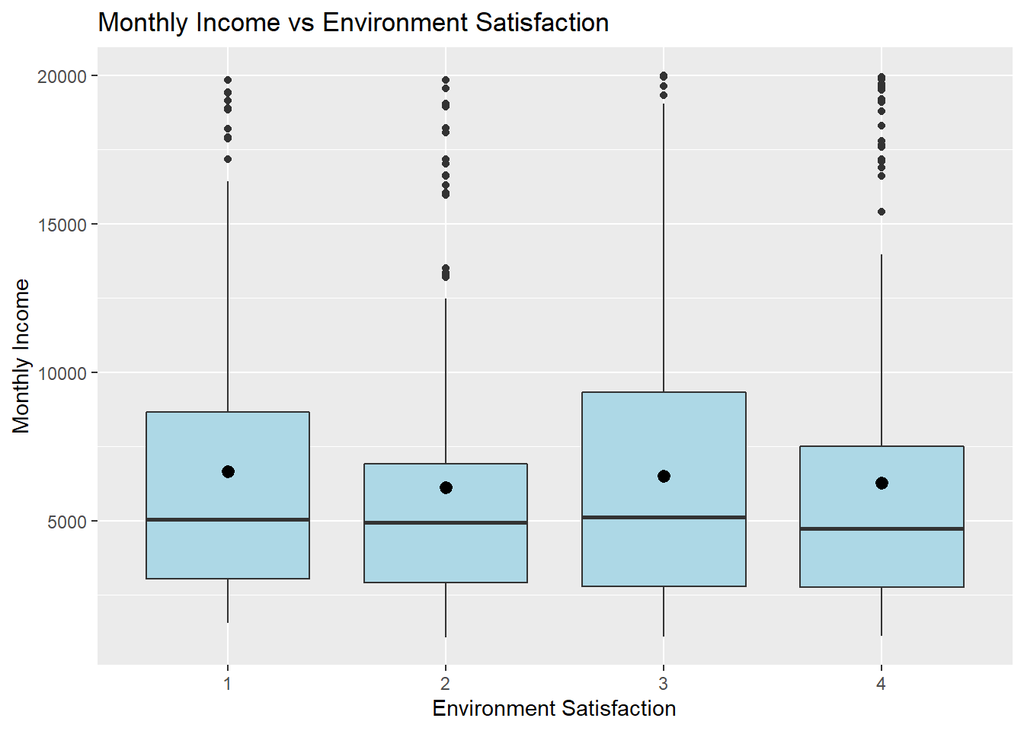

```r
sal_eda %>%
  ggplot(aes(x=EnvironmentSatisfaction,y= MonthlyIncome)) +
  geom_boxplot(fill = "lightblue") +
  stat_summary(fun=mean)  +
  ggtitle("Monthly Income vs Environment Satisfaction") +
  xlab("Environment Satisfaction") +
  ylab("Monthly Income")
```

Employees not satisfied with their environment tend to have a higher attrition rate.

### Gender

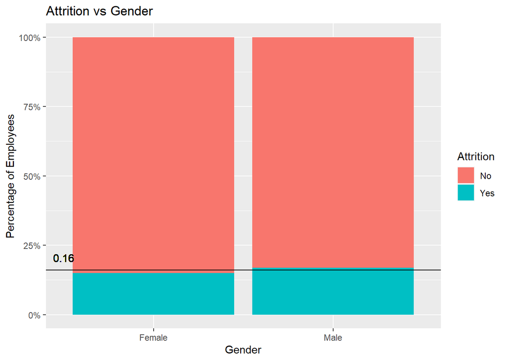

```r
sal_eda %>%
  ggplot(aes(x=Gender,fill=Attrition))+
  geom_bar(position = "fill")+
  ggtitle("Attrition vs Gender") +
  scale_y_continuous(labels = scales::percent) +
  geom_hline(aes(yintercept = h_line)) +
  geom_text(aes(0.5, h_line, label = h_line, vjust = - 1)) +
  xlab("Gender") +
  ylab("Percentage of Employees")
```

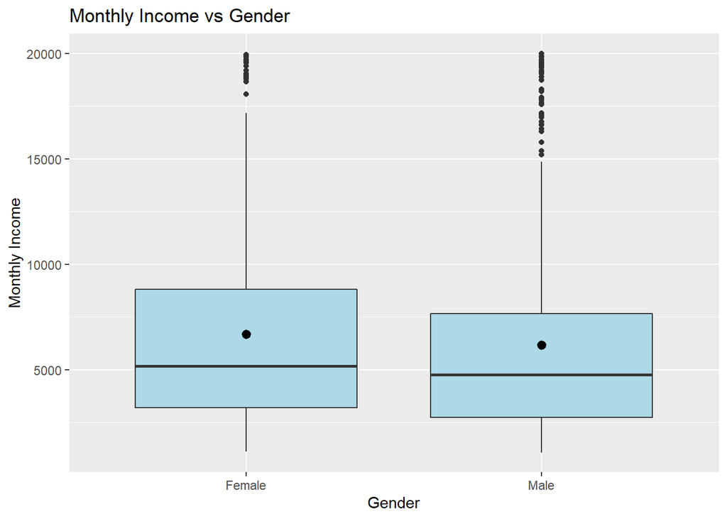

```r
sal_eda %>%
  ggplot(aes(x=Gender,y= MonthlyIncome)) +
  geom_boxplot(fill = "lightblue") +
  stat_summary(fun=mean)  +
  ggtitle("Monthly Income vs Gender") +
  xlab("Gender") +
  ylab("Monthly Income")
```

### Job Involvement

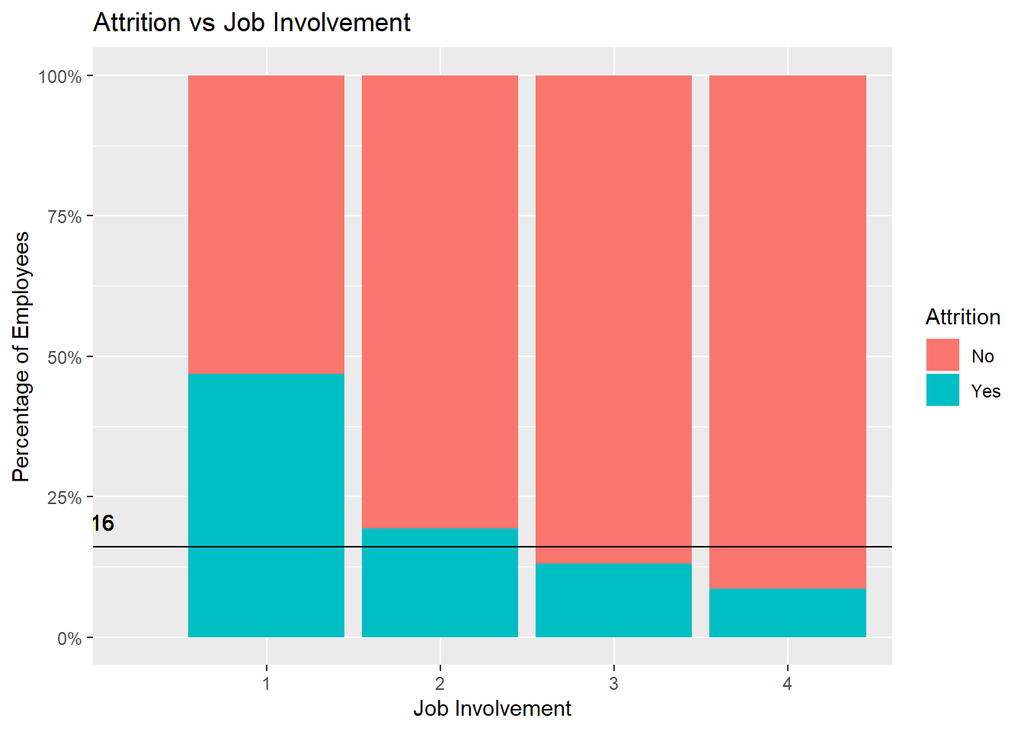

```r
sal_eda %>%
  ggplot(aes(x=JobInvolvement,fill=Attrition))+
  geom_bar(position = "fill")+
  ggtitle("Attrition vs Job Involvement") +
  scale_y_continuous(labels = scales::percent) +
  geom_hline(aes(yintercept = h_line)) +
  geom_text(aes(0, h_line, label = h_line, vjust = - 1)) +
  xlab("Job Involvement") +
  ylab("Percentage of Employees")
```

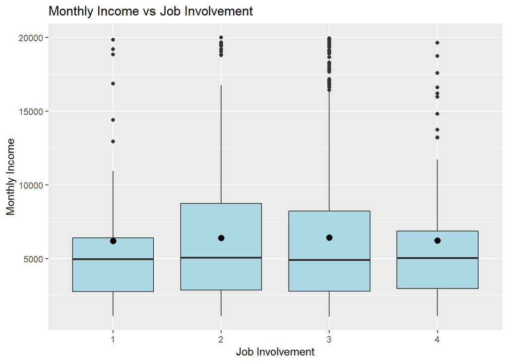

```r
sal_eda %>%
  ggplot(aes(x=JobInvolvement,y= MonthlyIncome)) +
  geom_boxplot(fill = "lightblue") +
  stat_summary(fun=mean)  +
  ggtitle("Monthly Income vs Job Involvement") +
  xlab("Job Involvement") +
  ylab("Monthly Income")
```

### Job Level

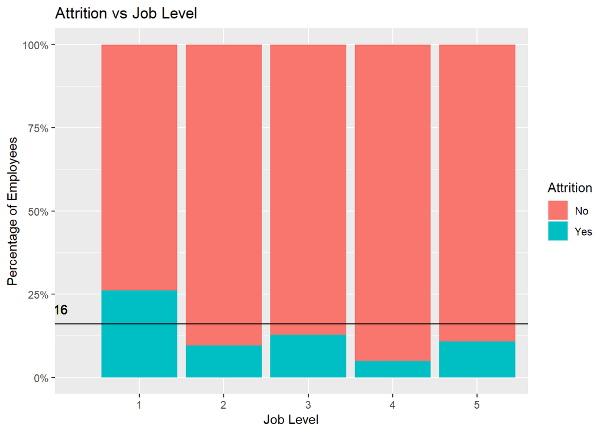

```r
sal_eda %>%
  ggplot(aes(x=JobLevel,fill=Attrition))+
  geom_bar(position = "fill")+
  ggtitle("Attrition vs Job Level") +
  scale_y_continuous(labels = scales::percent) +
  geom_hline(aes(yintercept = h_line)) +
  geom_text(aes(0, h_line, label = h_line, vjust = - 1)) +
  xlab("Job Level") +
  ylab("Percentage of Employees")
```

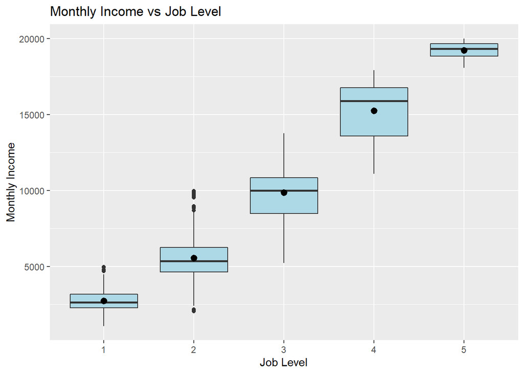

```r
sal_eda %>%
  ggplot(aes(x=JobLevel,y= MonthlyIncome)) +
  geom_boxplot(fill = "lightblue") +
  stat_summary(fun=mean)  +
  ggtitle("Monthly Income vs Job Level") +
  xlab("Job Level") +
  ylab("Monthly Income")
```

Higher job levels are associated with higher pay while lower job levels are associated with a higher attrition rate.

### Job Role

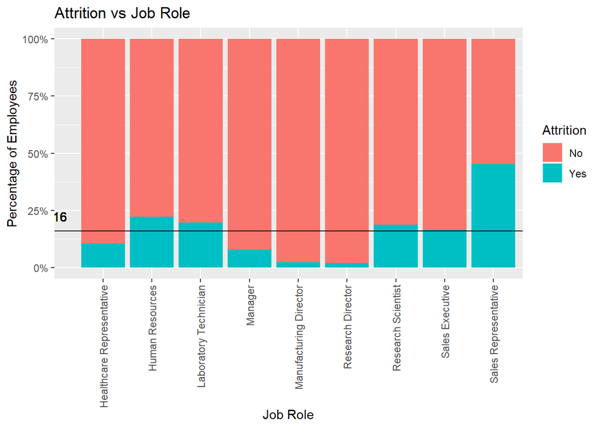

```r
sal_eda %>%
  ggplot(aes(x=JobRole,fill=Attrition))+
  geom_bar(position = "fill")+
  ggtitle("Attrition vs Job Role") +
  scale_y_continuous(labels = scales::percent) +
  geom_hline(aes(yintercept = h_line)) +
  geom_text(aes(0, h_line, label = h_line, vjust = - 1)) +
  xlab("Job Role") +
  ylab("Percentage of Employees")+
  theme(axis.text.x = element_text(angle = 90, vjust = 0.5, hjust=1))
```

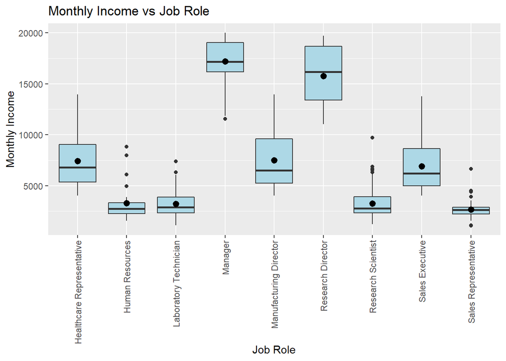

```r
sal_eda %>%
  ggplot(aes(x=JobRole,y= MonthlyIncome)) +
  geom_boxplot(fill = "lightblue") +
  stat_summary(fun=mean)  +
  ggtitle("Monthly Income vs Job Role") +
  xlab("Job Role") +
  ylab("Monthly Income")+
  theme(axis.text.x = element_text(angle = 90, vjust = 0.5, hjust=1))
```

Managers and Research Directors make the highest salaries. The data also shows that employees in sales tend to have the highest attrition rates.

### Job Satisfaction

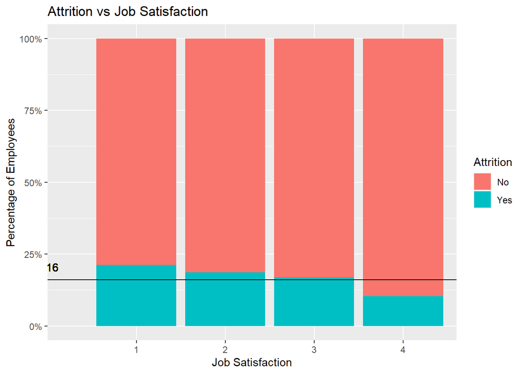

```r
sal_eda %>%
  ggplot(aes(x=JobSatisfaction,fill=Attrition))+
  geom_bar(position = "fill")+
  ggtitle("Attrition vs Job Satisfaction") +
  scale_y_continuous(labels = scales::percent) +
  geom_hline(aes(yintercept = h_line)) +
  geom_text(aes(0, h_line, label = h_line, vjust = - 1)) +
  xlab("Job Satisfaction") +
  ylab("Percentage of Employees")
```

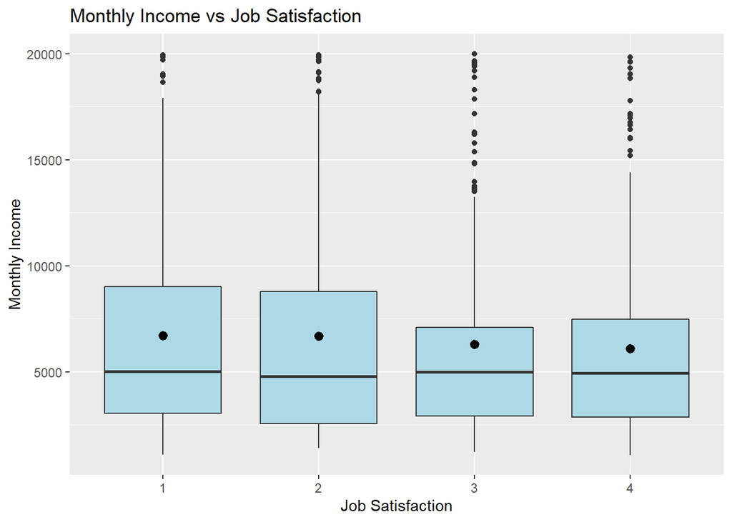

```r
sal_eda %>%
  ggplot(aes(x=JobSatisfaction,y= MonthlyIncome)) +
  geom_boxplot(fill = "lightblue") +
  stat_summary(fun=mean)  +
  ggtitle("Monthly Income vs Job Satisfaction") +
  xlab("Job Satisfaction") +
  ylab("Monthly Income")
```

Job satisfaction looks to have a relatively equal variance for salaries; however, lower satisfaction is associated with a higher attrition rate.

### Marital Status

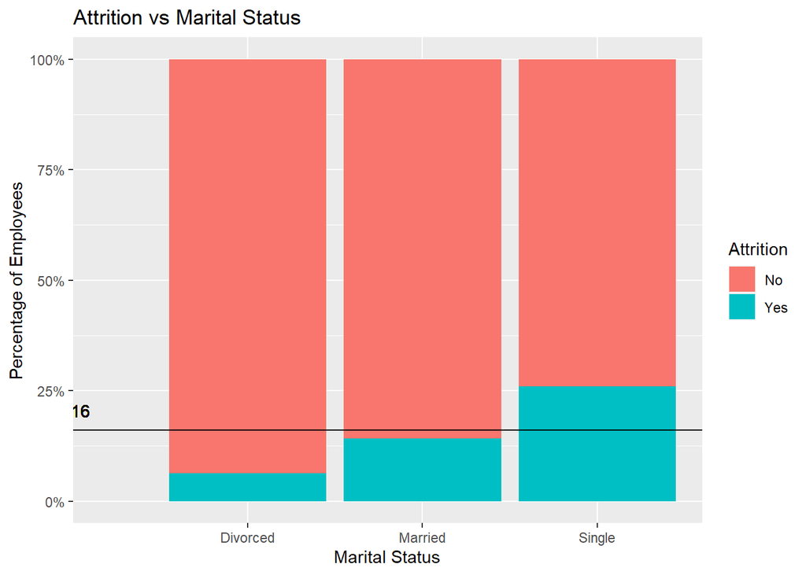

```r
sal_eda %>%
  ggplot(aes(x=MaritalStatus,fill=Attrition))+
  geom_bar(position = "fill")+
  ggtitle("Attrition vs Marital Status") +
  scale_y_continuous(labels = scales::percent) +
  geom_hline(aes(yintercept = h_line)) +
  geom_text(aes(0, h_line, label = h_line, vjust = - 1)) +
  xlab("Marital Status") +
  ylab("Percentage of Employees")
```

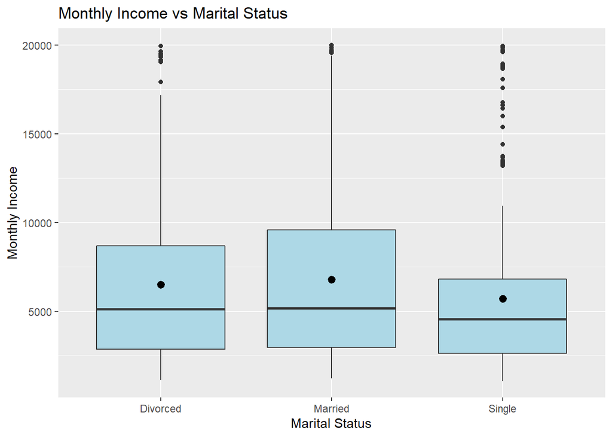

```r
sal_eda %>%
  ggplot(aes(x=MaritalStatus,y= MonthlyIncome)) +
  geom_boxplot(fill = "lightblue") +
  stat_summary(fun=mean)  +
  ggtitle("Monthly Income vs Marital Status") +
  xlab("Marital Status") +
  ylab("Monthly Income")
```

Single employees tend to quit in higher percentages and have the lowest variance in salaries.

### Number of Comapnies Worked

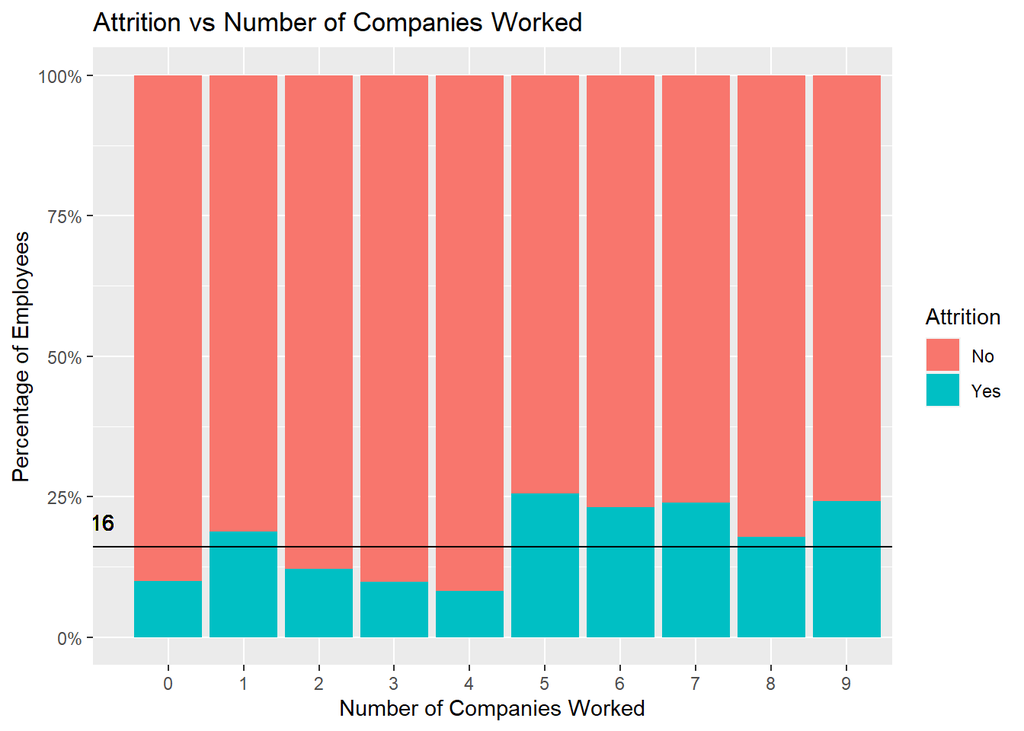

```r
sal_eda %>%
  ggplot(aes(x=NumCompaniesWorked,fill=Attrition))+
  geom_bar(position = "fill")+
  ggtitle("Attrition vs Number of Companies Worked") +
  scale_y_continuous(labels = scales::percent) +
  geom_hline(aes(yintercept = h_line)) +
  geom_text(aes(0, h_line, label = h_line, vjust = - 1)) +
  xlab("Number of Companies Worked") +
  ylab("Percentage of Employees")
```

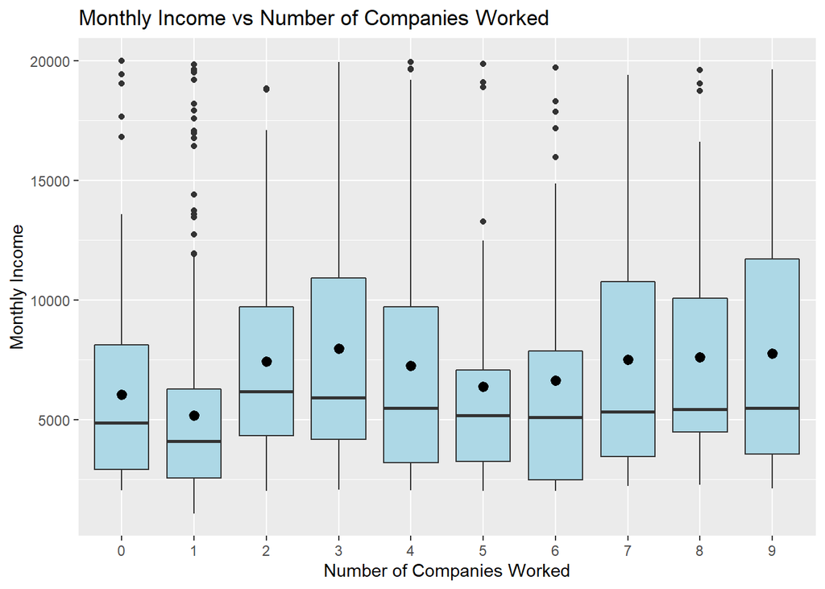

```r
sal_eda %>%
  ggplot(aes(x=NumCompaniesWorked,y= MonthlyIncome)) +
  geom_boxplot(fill = "lightblue") +
  stat_summary(fun=mean)  +
  ggtitle("Monthly Income vs Number of Companies Worked") +
  xlab("Number of Companies Worked") +
  ylab("Monthly Income")
```

Employees who have hopped around more tend to have a higher attrition rate. The salaries though are relatively equal in variance.

### Over Time

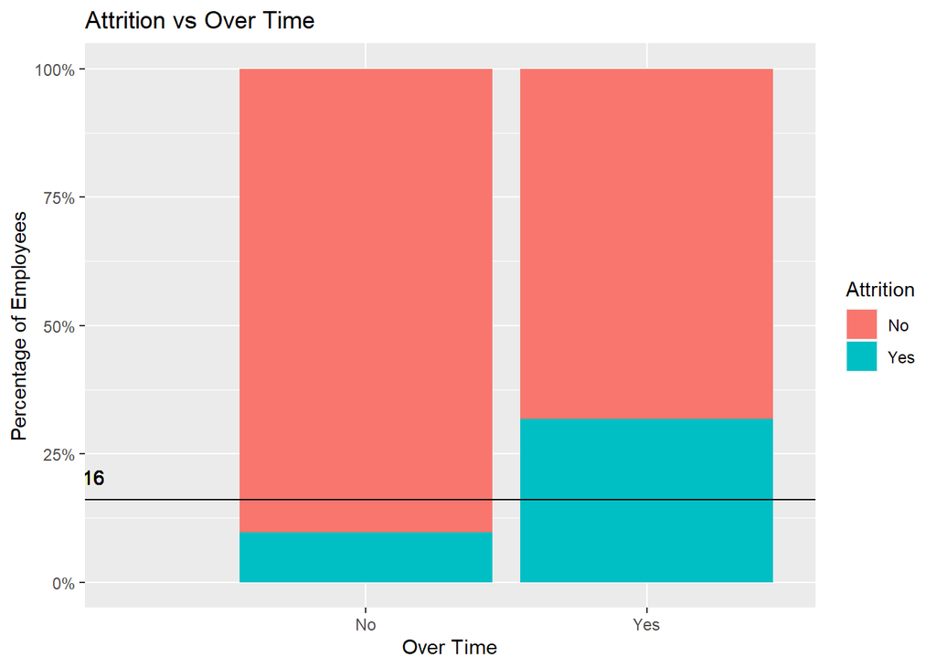

```r
sal_eda %>%
  ggplot(aes(x=OverTime,fill=Attrition))+
  geom_bar(position = "fill")+
  ggtitle("Attrition vs Over Time") +
  scale_y_continuous(labels = scales::percent) +
  geom_hline(aes(yintercept = h_line)) +
  geom_text(aes(0, h_line, label = h_line, vjust = - 1)) +
  xlab("Over Time") +
  ylab("Percentage of Employees")
```

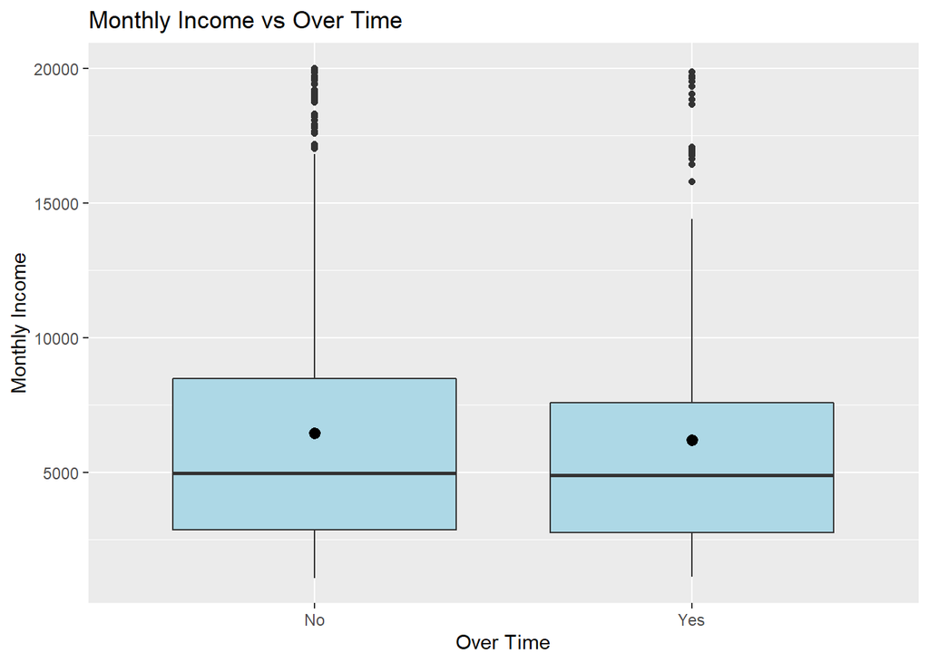

```r
sal_eda %>%
  ggplot(aes(x=OverTime,y= MonthlyIncome)) +
  geom_boxplot(fill = "lightblue") +
  stat_summary(fun=mean)  +
  ggtitle("Monthly Income vs Over Time") +
  xlab("Over Time") +
  ylab("Monthly Income")
```

Employees with higher rates of over time are associated with higher attrition rates; however, there is no change in monthly income between employees who do and do not.

### Percent Salary Hike

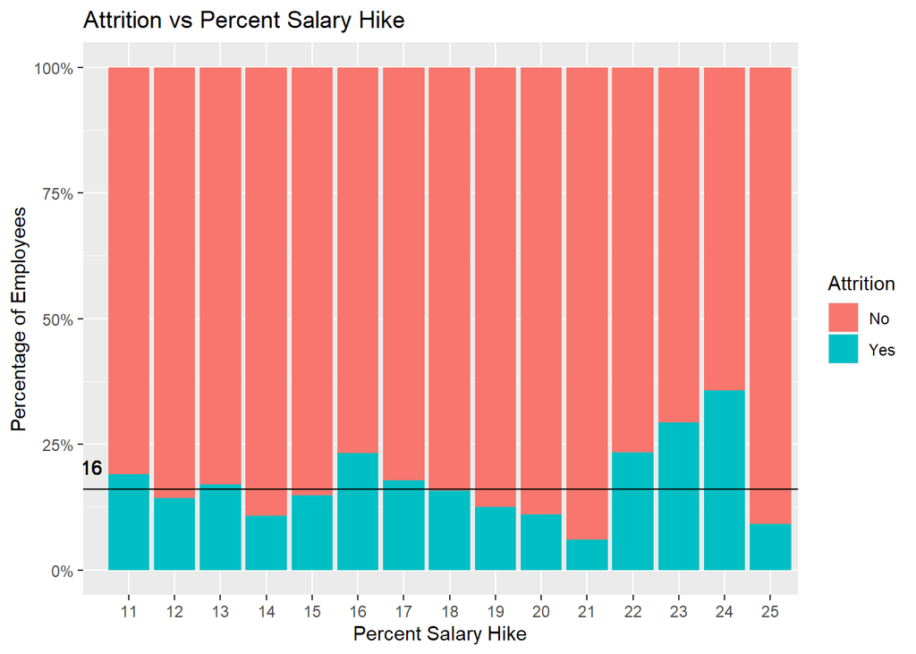

```r
sal_eda %>%
  ggplot(aes(x=PercentSalaryHike,fill=Attrition))+
  geom_bar(position = "fill")+
  ggtitle("Attrition vs Percent Salary Hike") +
  scale_y_continuous(labels = scales::percent) +
  geom_hline(aes(yintercept = h_line)) +
  geom_text(aes(0, h_line, label = h_line, vjust = - 1)) +
  xlab("Percent Salary Hike") +
  ylab("Percentage of Employees")
```

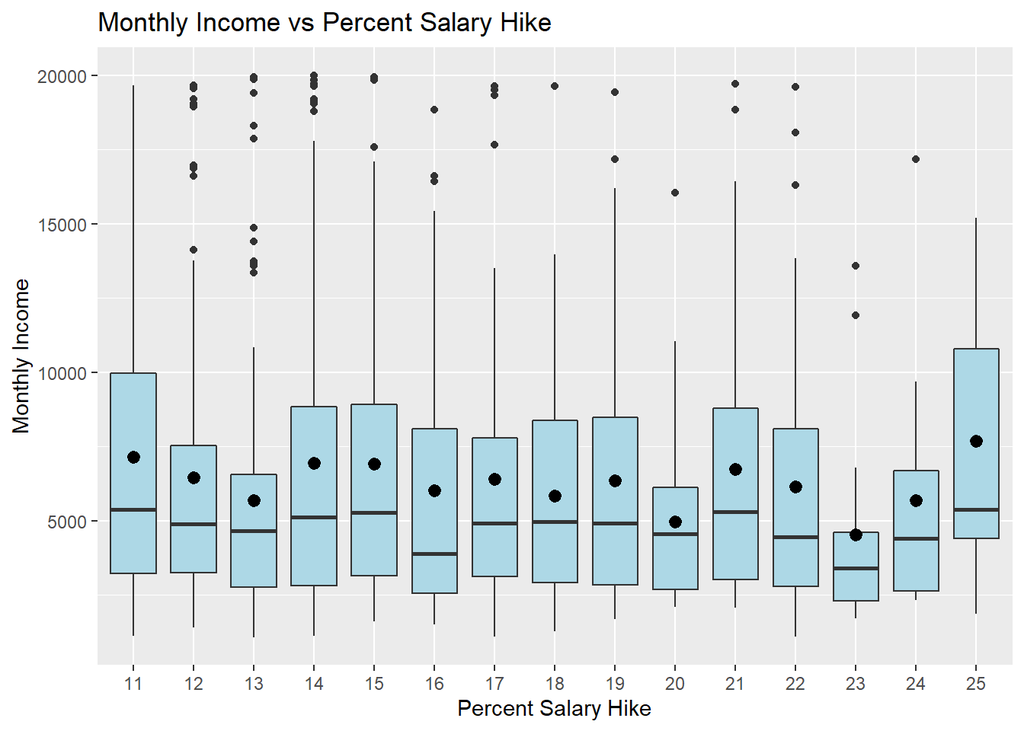

```r
sal_eda %>%
  ggplot(aes(x=PercentSalaryHike,y= MonthlyIncome)) +
  geom_boxplot(fill = "lightblue") +
  stat_summary(fun=mean)  +
  ggtitle("Monthly Income vs Percent Salary Hike") +
  xlab("Percent Salary Hike") +
  ylab("Monthly Income")
```

### Performance Rating

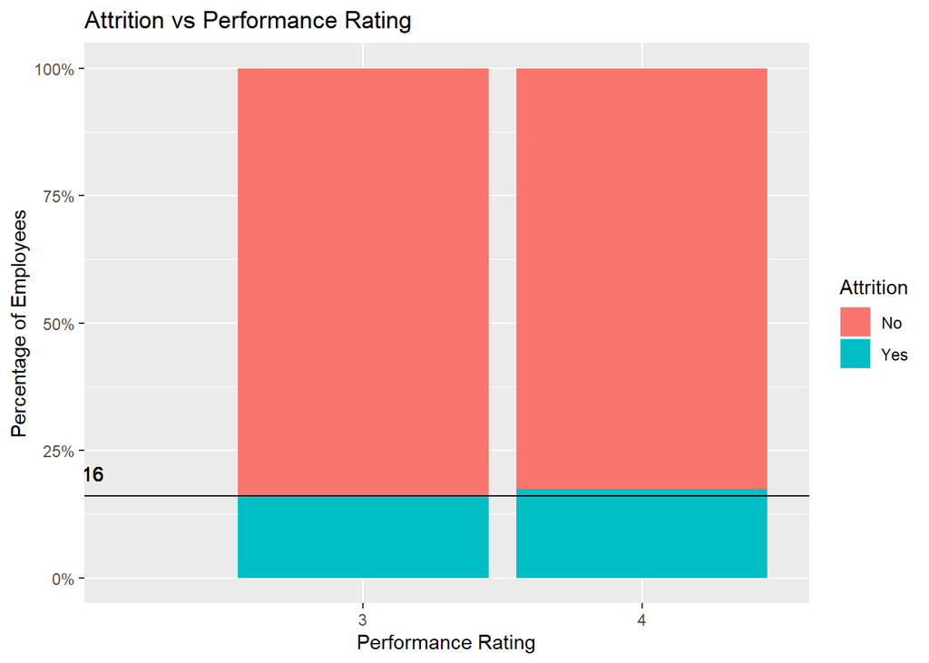

```r
sal_eda %>%
  ggplot(aes(x=PerformanceRating,fill=Attrition))+
  geom_bar(position = "fill")+
  ggtitle("Attrition vs Performance Rating") +
  scale_y_continuous(labels = scales::percent) +
  geom_hline(aes(yintercept = h_line)) +
  geom_text(aes(0, h_line, label = h_line, vjust = - 1)) +
  xlab("Performance Rating") +
  ylab("Percentage of Employees")
```

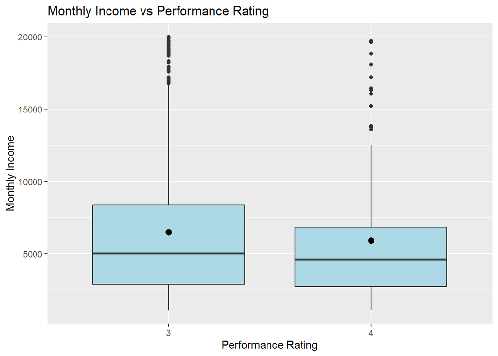

```r
sal_eda %>%
  ggplot(aes(x=PerformanceRating,y= MonthlyIncome)) +
  geom_boxplot(fill = "lightblue") +
  stat_summary(fun=mean)  +
  ggtitle("Monthly Income vs Performance Rating") +
  xlab("Performance Rating") +
  ylab("Monthly Income")
```

Performance rating (between a 3 and a 4) looks to have very little effect on either Attrition rate or Monthly Income

### Relationship Satisfaction

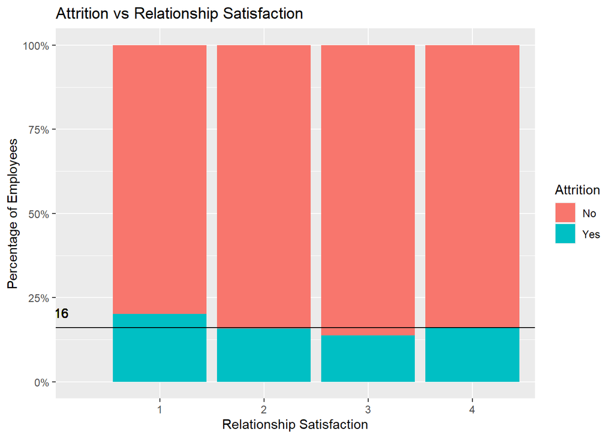

```r
sal_eda %>%
  ggplot(aes(x=RelationshipSatisfaction,fill=Attrition))+
  geom_bar(position = "fill")+
  ggtitle("Attrition vs Relationship Satisfaction") +
  scale_y_continuous(labels = scales::percent) +
  geom_hline(aes(yintercept = h_line)) +
  geom_text(aes(0, h_line, label = h_line, vjust = - 1)) +
  xlab("Relationship Satisfaction") +
  ylab("Percentage of Employees")
```

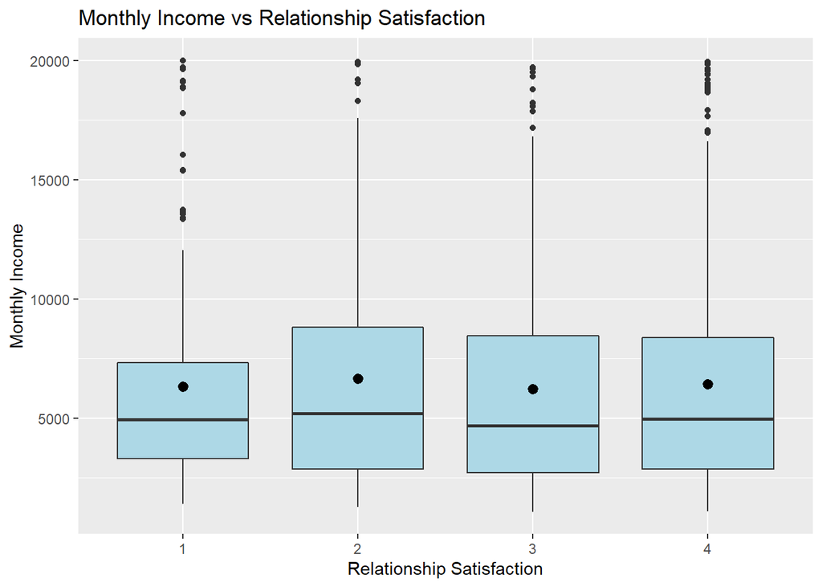

```r
sal_eda %>%
  ggplot(aes(x=RelationshipSatisfaction,y= MonthlyIncome)) +
  geom_boxplot(fill = "lightblue") +
  stat_summary(fun=mean)  +
  ggtitle("Monthly Income vs Relationship Satisfaction") +
  xlab("Relationship Satisfaction") +
  ylab("Monthly Income")
```

Employees with a lower Relationship Status look to have a higher rate of Attrition, but no change in the mean monthly income.

### Stock Option Level

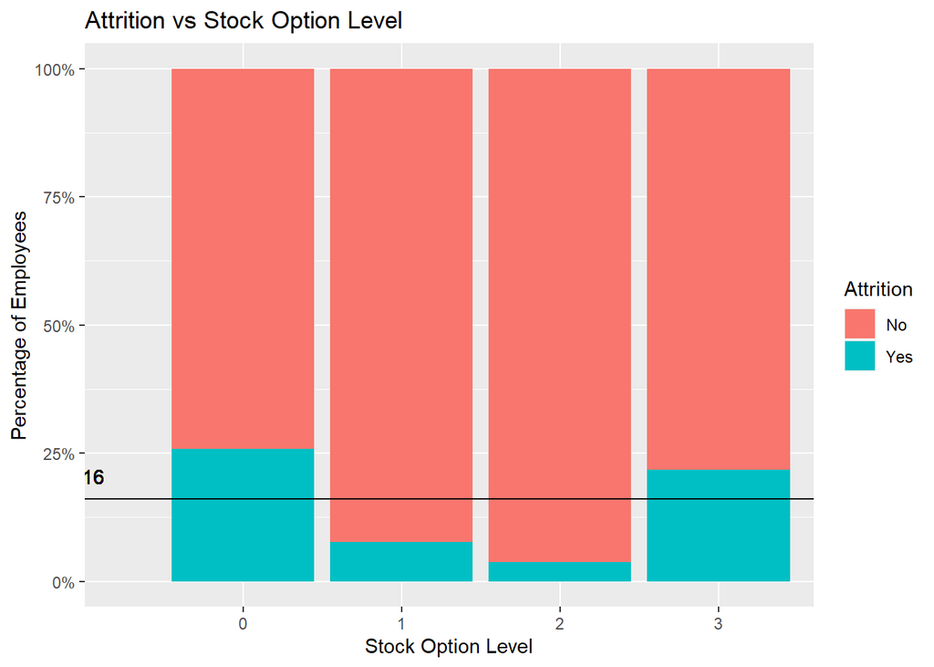

```r
sal_eda %>%
  ggplot(aes(x=StockOptionLevel,fill=Attrition))+
  geom_bar(position = "fill")+
  ggtitle("Attrition vs Stock Option Level") +
  scale_y_continuous(labels = scales::percent) +
  geom_hline(aes(yintercept = h_line)) +
  geom_text(aes(0, h_line, label = h_line, vjust = - 1)) +
  xlab("Stock Option Level") +
  ylab("Percentage of Employees")
```

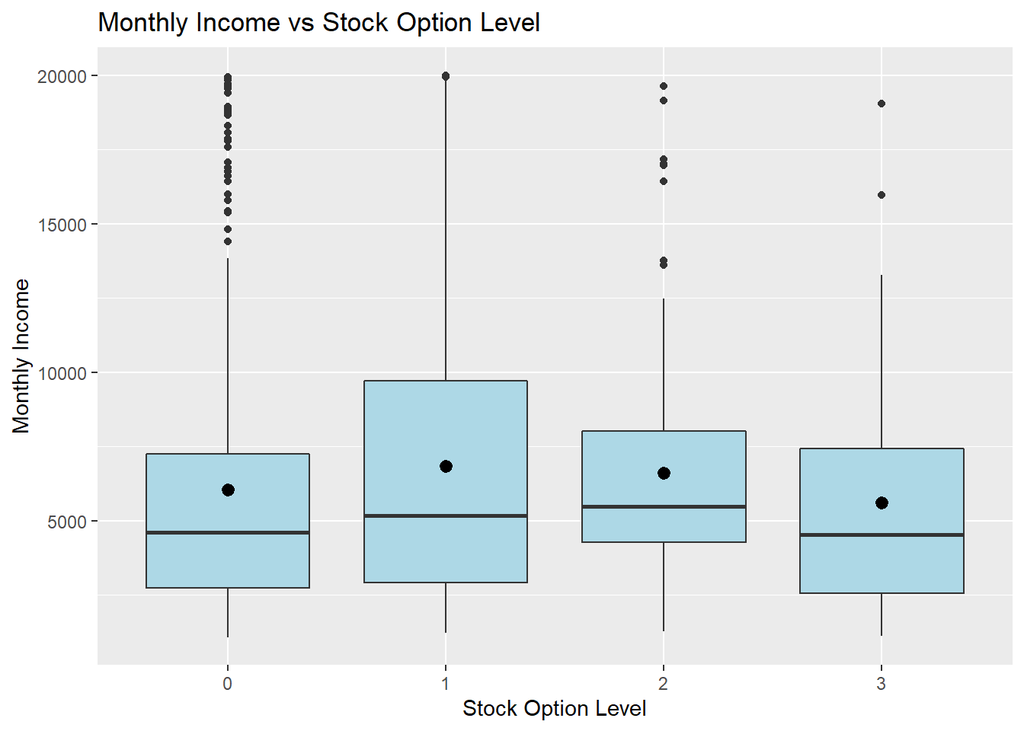

```r
sal_eda %>%
  ggplot(aes(x=StockOptionLevel,y= MonthlyIncome)) +
  geom_boxplot(fill = "lightblue") +
  stat_summary(fun=mean)  +
  ggtitle("Monthly Income vs Stock Option Level") +
  xlab("Stock Option Level") +
  ylab("Monthly Income")
```

Employees with either 0 stock option level or the highest have the highest rates of attrition. This could be either lower level employees for no stock option or executives closer to retirement. But Stock option levels don’t have any variance in the mean of the monthly income.

# Stock Option Levels vs Age and Income

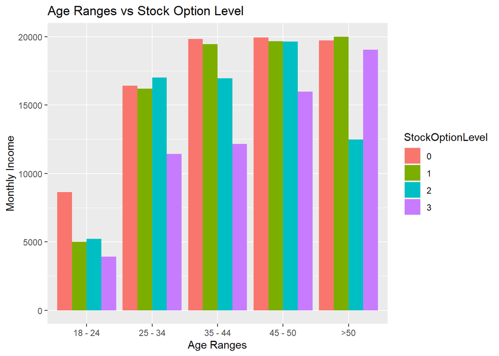

```r
sal_eda %>%
  ggplot(aes(x=AgeRange,y = MonthlyIncome, fill=StockOptionLevel))+
  geom_col(position = "dodge")+
  ggtitle("Age Ranges vs Stock Option Level") +
  xlab("Age Ranges") +
  ylab("Monthly Income")
```

### Total Working Years

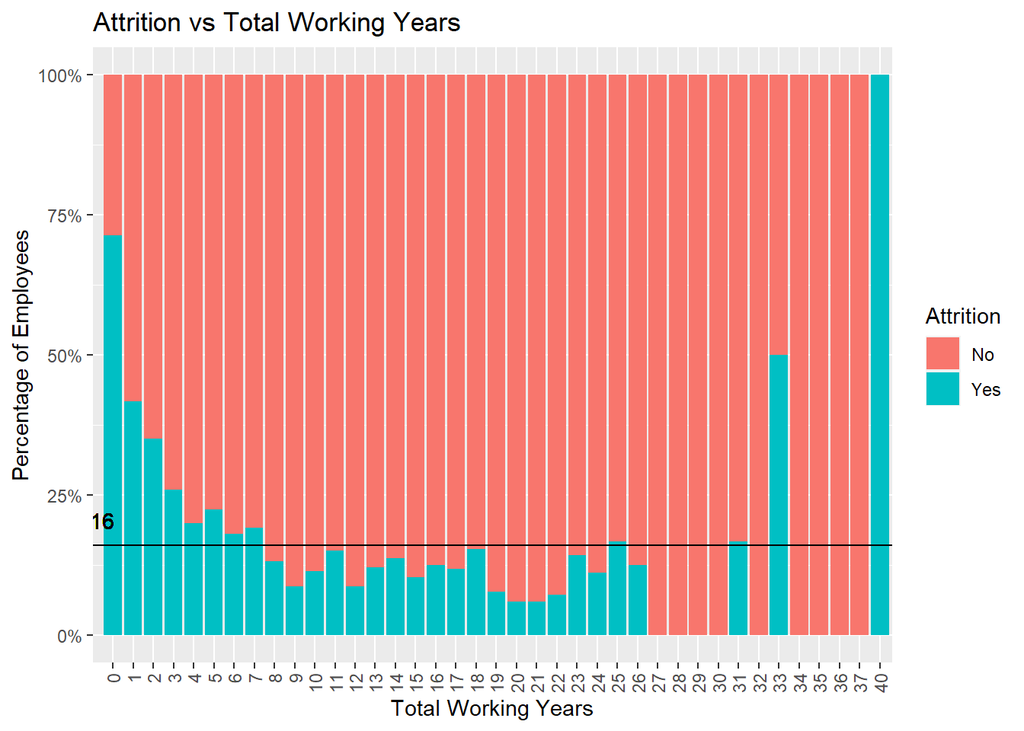

```r
sal_eda %>%
  ggplot(aes(x=TotalWorkingYears,fill=Attrition))+
  geom_bar(position = "fill")+
  ggtitle("Attrition vs Total Working Years") +
  scale_y_continuous(labels = scales::percent) +
  geom_hline(aes(yintercept = h_line)) +
  geom_text(aes(0, h_line, label = h_line, vjust = - 1)) +
  xlab("Total Working Years") +
  ylab("Percentage of Employees") +
  theme(axis.text.x = element_text(angle = 90, vjust = 0.5, hjust=1))
```

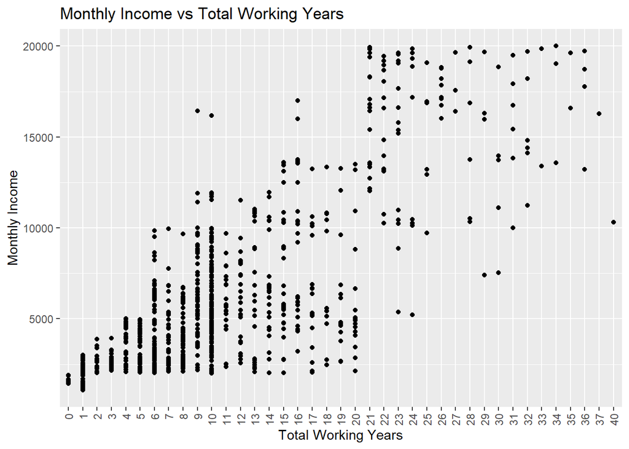

```r
sal_eda %>%
  ggplot(aes(x=TotalWorkingYears,y= MonthlyIncome)) +
  geom_point() + geom_smooth(method = "lm") +
  ggtitle("Monthly Income vs Total Working Years") +
  xlab("Total Working Years") +
  ylab("Monthly Income") +
  theme(axis.text.x = element_text(angle = 90, vjust = 0.5, hjust=1))
```

Less experienced employees are associated with a higher attrition rate. Same goes for employees with 31+ years (due to retirement likely). Also, employees with more years of experience are also associated with higher salaries.

### Times Trained in the last year

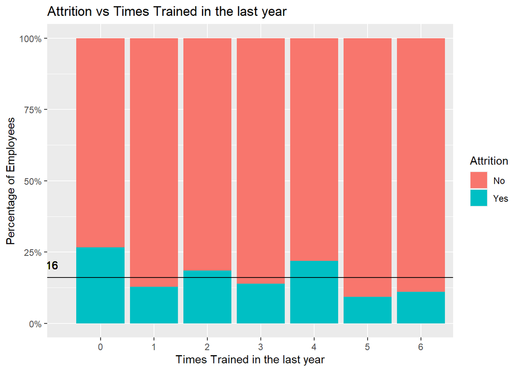

```r
sal_eda %>%
  ggplot(aes(x=TrainingTimesLastYear,fill=Attrition))+
  geom_bar(position = "fill")+
  ggtitle("Attrition vs Times Trained in the last year") +
  scale_y_continuous(labels = scales::percent) +
  geom_hline(aes(yintercept = h_line)) +
  geom_text(aes(0, h_line, label = h_line, vjust = - 1)) +
  xlab("Times Trained in the last year") +
  ylab("Percentage of Employees")
```

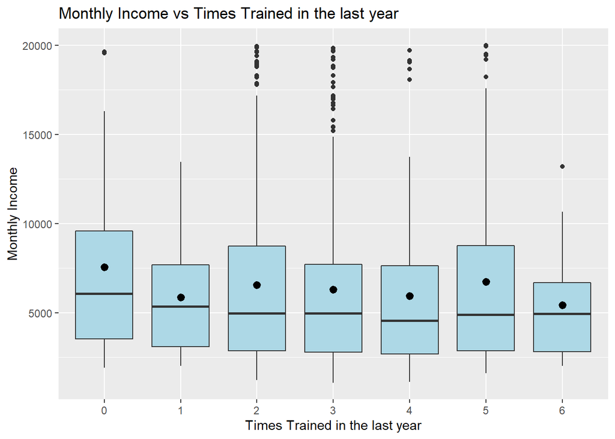

```r
sal_eda %>%
  ggplot(aes(x=TrainingTimesLastYear,y= MonthlyIncome)) +
  geom_boxplot(fill = "lightblue") +
  stat_summary(fun=mean)  +
  ggtitle("Monthly Income vs Times Trained in the last year") +
  xlab("Times Trained in the last year") +
  ylab("Monthly Income")
```

### Work Life Balance

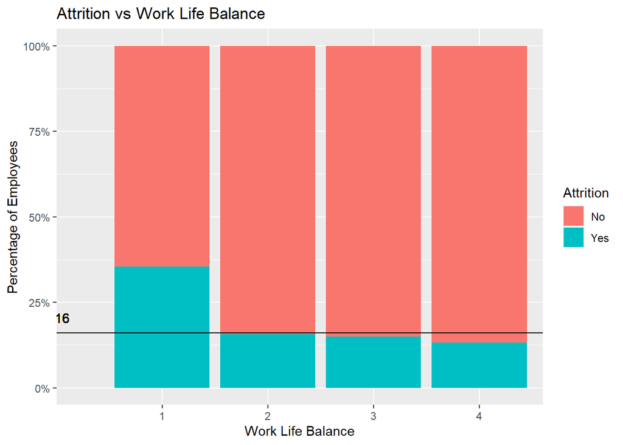

```r
sal_eda %>%
  ggplot(aes(x=WorkLifeBalance,fill=Attrition))+
  geom_bar(position = "fill")+
  ggtitle("Attrition vs Work Life Balance") +
  scale_y_continuous(labels = scales::percent) +
  geom_hline(aes(yintercept = h_line)) +
  geom_text(aes(0, h_line, label = h_line, vjust = - 1)) +
  xlab("Work Life Balance") +
  ylab("Percentage of Employees")
```

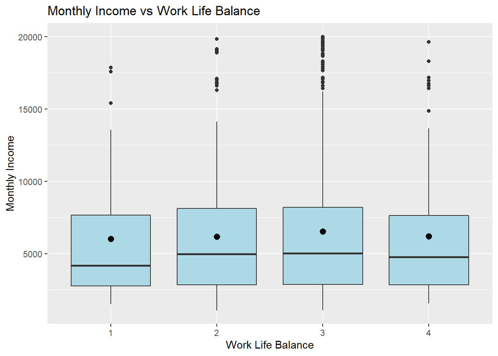

```r
sal_eda %>%
  ggplot(aes(x=WorkLifeBalance,y= MonthlyIncome)) +
  geom_boxplot(fill = "lightblue") +
  stat_summary(fun=mean)  +
  ggtitle("Monthly Income vs Work Life Balance") +
  xlab("Work Life Balance") +
  ylab("Monthly Income")
```

Employees with lower work/life balance have a higher chance of quitting vs employees with a better balance.

### Years at Company

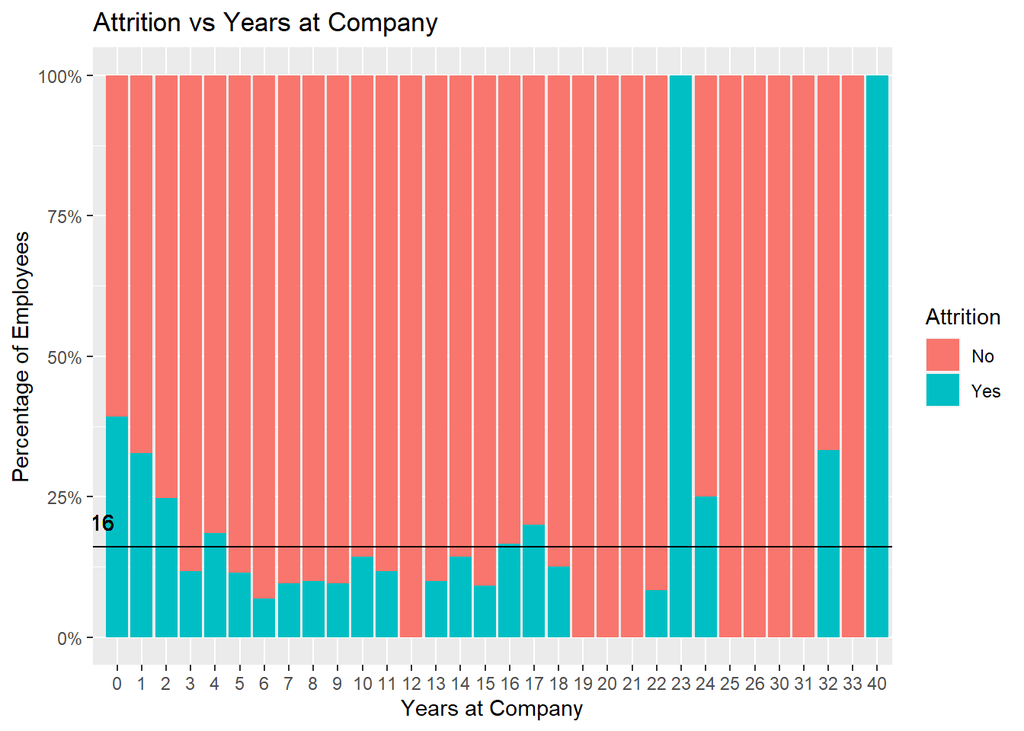

```r
sal_eda %>%
  ggplot(aes(x=YearsAtCompany,fill=Attrition))+
  geom_bar(position = "fill")+
  ggtitle("Attrition vs Years at Company") +
  scale_y_continuous(labels = scales::percent) +
  geom_hline(aes(yintercept = h_line)) +
  geom_text(aes(0, h_line, label = h_line, vjust = - 1)) +
  xlab("Years at Company") +
  ylab("Percentage of Employees")
```

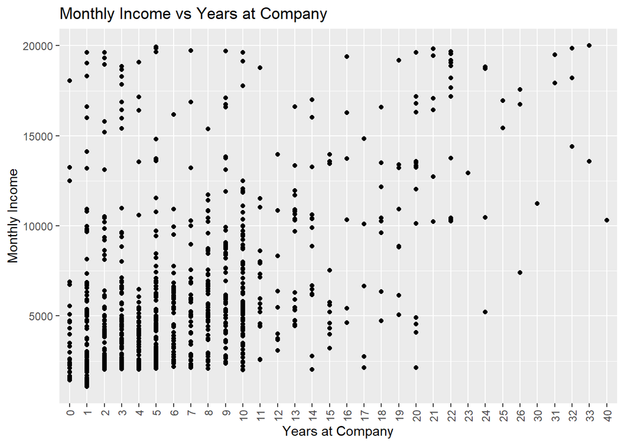

```r
sal_eda %>%
  ggplot(aes(x=YearsAtCompany,y= MonthlyIncome)) +
  geom_point() + geom_smooth(method = "lm") +
  ggtitle("Monthly Income vs Years at Company") +
  xlab("Years at Company") +
  ylab("Monthly Income") +
  theme(axis.text.x = element_text(angle = 90, vjust = 0.5, hjust=1))
```

Much like Total Working Years, employees who have been with the company for the shortest amount of time have a higher chance of attrition as well as employees who have been with the company the longest (retirement is likely the culprit again). And the longer an employee is with the company, the higher their chance for a higher salary.

### Years in Current Role

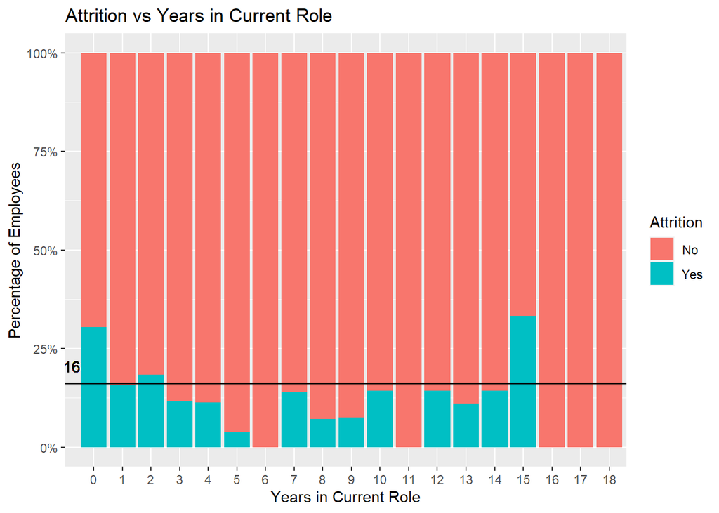

```r
sal_eda %>%
  ggplot(aes(x=YearsInCurrentRole,fill=Attrition))+
  geom_bar(position = "fill")+
  ggtitle("Attrition vs Years in Current Role") +
  scale_y_continuous(labels = scales::percent) +
  geom_hline(aes(yintercept = h_line)) +
  geom_text(aes(0, h_line, label = h_line, vjust = - 1)) +
  xlab("Years in Current Role") +
  ylab("Percentage of Employees")
```

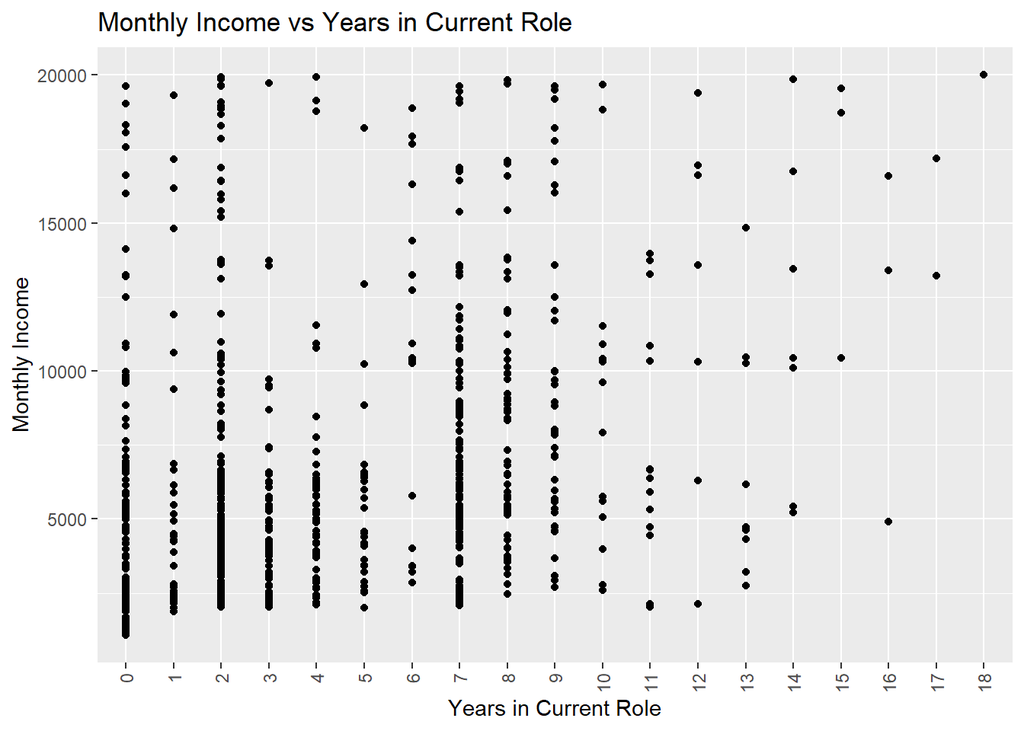

```r
sal_eda %>%
  ggplot(aes(x=YearsInCurrentRole,y= MonthlyIncome)) +
  geom_point() + geom_smooth(method = "lm") +
  ggtitle("Monthly Income vs Years in Current Role") +
  xlab("Years in Current Role") +
  ylab("Monthly Income") +
  theme(axis.text.x = element_text(angle = 90, vjust = 0.5, hjust=1))
```

It looks like only the two bookends (shortest and longest at current role) tend to have any kind of visible effect on attrition rate.

### Years since Last Promotion

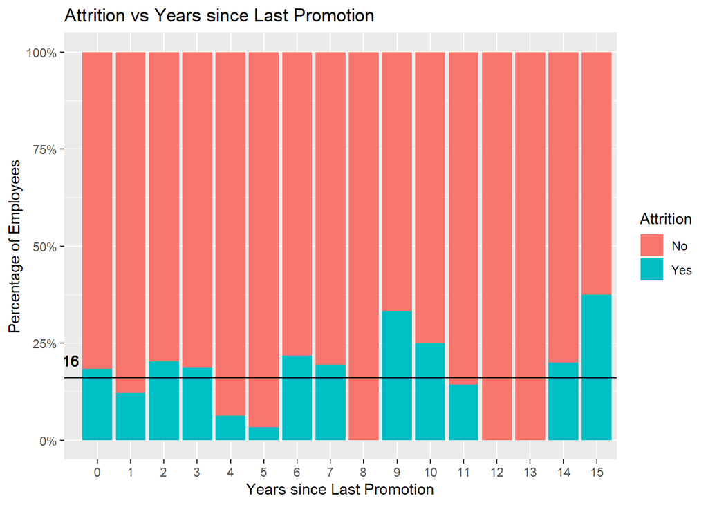

```r
sal_eda %>%
  ggplot(aes(x=YearsSinceLastPromotion,fill=Attrition))+
  geom_bar(position = "fill")+
  ggtitle("Attrition vs Years since Last Promotion") +
  scale_y_continuous(labels = scales::percent) +
  geom_hline(aes(yintercept = h_line)) +
  geom_text(aes(0, h_line, label = h_line, vjust = - 1)) +
  xlab("Years since Last Promotion") +
  ylab("Percentage of Employees")
```

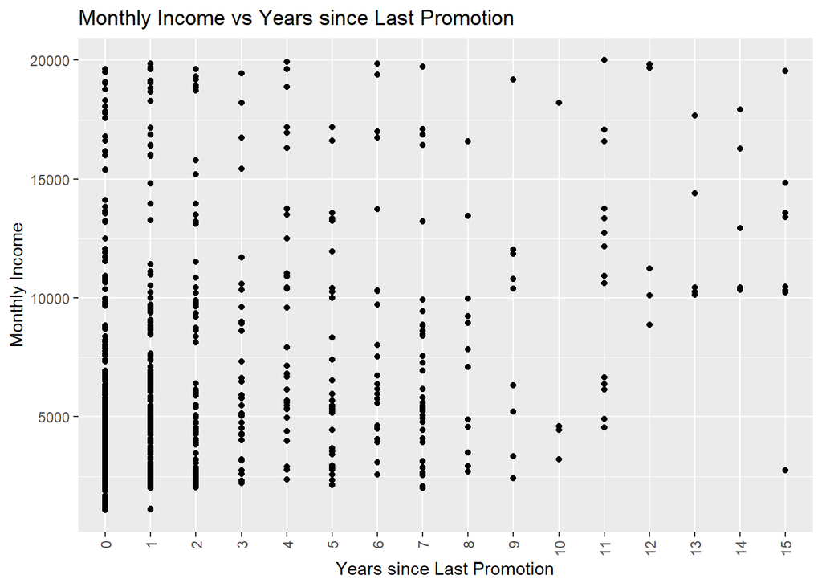

```r
sal_eda %>%
  ggplot(aes(x=YearsSinceLastPromotion,y= MonthlyIncome)) +
  geom_point() + geom_smooth(method = "lm") +
  ggtitle("Monthly Income vs Years since Last Promotion") +
  xlab("Years since Last Promotion") +
  ylab("Monthly Income") +
  theme(axis.text.x = element_text(angle = 90, vjust = 0.5, hjust=1))
```

### Years with Current Manager

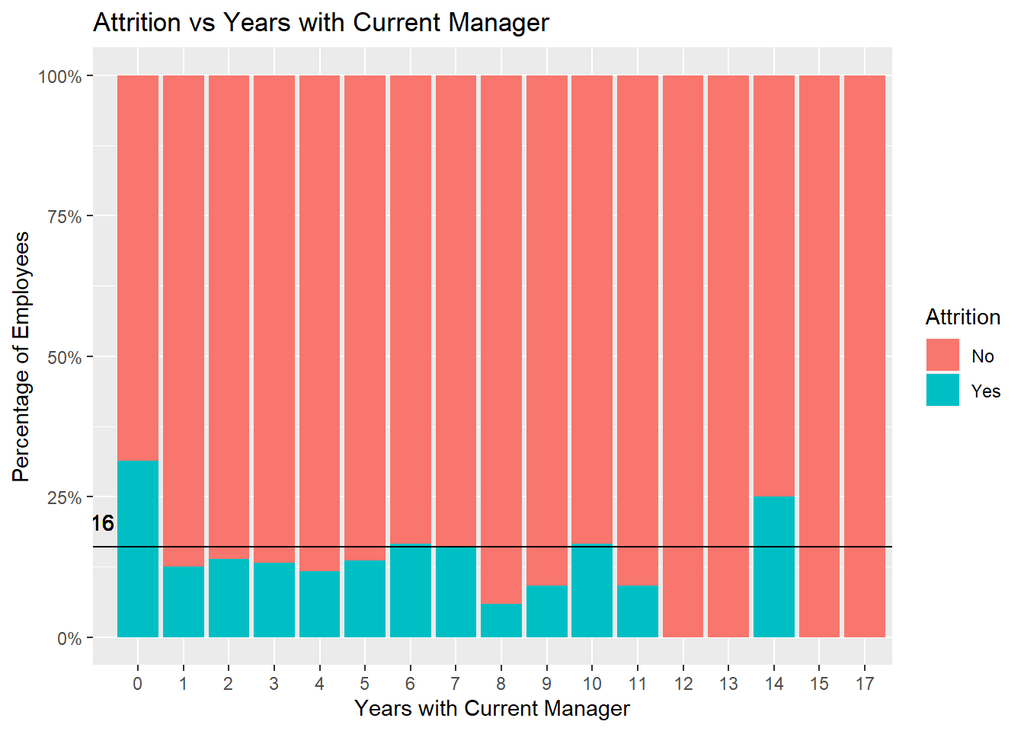

```r
sal_eda %>%
  ggplot(aes(x=YearsWithCurrManager,fill=Attrition))+
  geom_bar(position = "fill")+
  ggtitle("Attrition vs Years with Current Manager") +
  scale_y_continuous(labels = scales::percent) +
  geom_hline(aes(yintercept = h_line)) +
  geom_text(aes(0, h_line, label = h_line, vjust = - 1)) +
  xlab("Years with Current Manager") +
  ylab("Percentage of Employees")
```

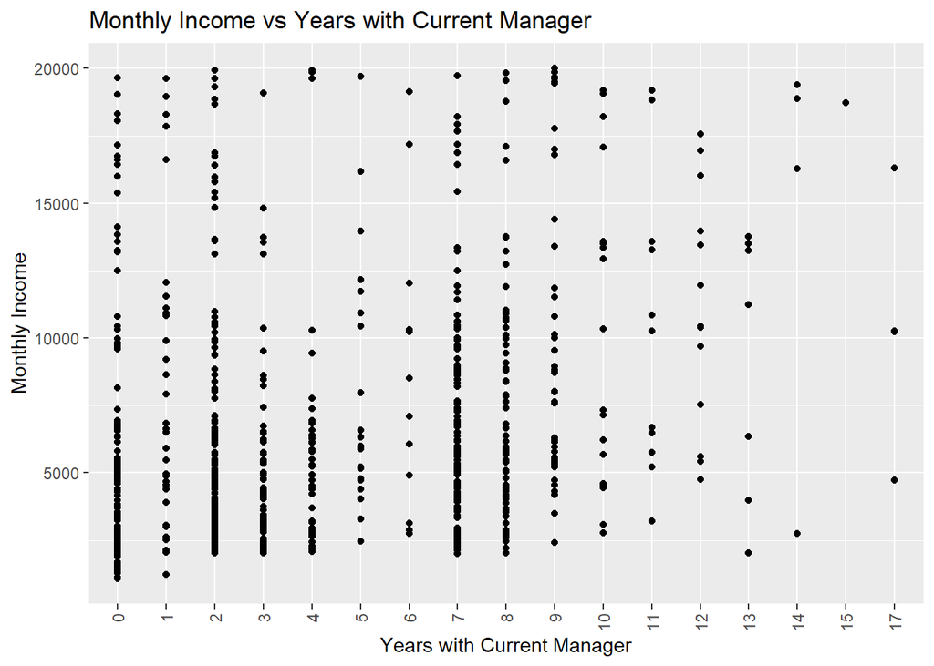

```r
sal_eda %>%
  ggplot(aes(x=YearsWithCurrManager,y= MonthlyIncome)) +
  geom_point() + geom_smooth(method = "lm") +
  ggtitle("Monthly Income vs Years with Current Manager") +
  xlab("Years with Current Manager") +
  ylab("Monthly Income") +
  theme(axis.text.x = element_text(angle = 90, vjust = 0.5, hjust=1))
```

# KNN and Naive Bayes Predictions For Attrition Rate

## KNN

### Finding the best variables using forward, backward, and step-wise selection

First, we can create a clean KNN dataset to use to build our 3 models off of. This clean data set will remove any variable we cannot create in either binary or is non-numerical. KNN uses Euclidian distances, so categorical variables that use levels will not apply, thus will be left out; however, binary can still be useful in determining the prediction.

```r
sal_knn <- select(sal_data, -c("BusinessTravel", "Department", "EducationField", "JobRole", "MaritalStatus"))

sal_knn$OverTime = ifelse(sal_knn$OverTime == "Yes", 1, 0)
sal_knn$Attrition = ifelse(sal_knn$Attrition == "Yes", 1, 0)
sal_knn$Gender = ifelse(sal_knn$Gender == "Male", 1, 0)

# Forward Selection
best_subset_forward <-
  regsubsets(Attrition~.,
             data = sal_knn,
             nbest = 1,
             nvmax = NULL,
             force.in = NULL, force.out = NULL,
             method = "forward")

# Backward Selection
best_subset_backward <-
  regsubsets(Attrition~.,
             data = sal_knn,
             nbest = 1,
             nvmax = NULL,
             force.in = NULL, force.out = NULL,
             method = "backward")

# Sequential/Stepwise Selection
best_subset_stpwse <-
  regsubsets(Attrition~.,
             data = sal_knn,
             nbest = 1,
             nvmax = NULL,
             force.in = NULL, force.out = NULL,
             method = "seqrep")

forward_summary <- summary(best_subset_backward)
as.data.frame(forward_summary$outmat)
```

```
##           Age DailyRate DistanceFromHome Education EnvironmentSatisfaction
## 1  ( 1 )
## 2  ( 1 )
## 3  ( 1 )
## 4  ( 1 )
## 5  ( 1 )
## 6  ( 1 )
## 7  ( 1 )                                                                 *
## 8  ( 1 )                                                                 *
## 9  ( 1 )                               *                                 *
## 10  ( 1 )                              *                                 *
## 11  ( 1 )                              *                                 *
## 12  ( 1 )   *                          *                                 *
## 13  ( 1 )   *                          *                                 *
## 14  ( 1 )   *                          *                                 *
```

[output cut: 167 more lines]

```r
backward_summary <- summary(best_subset_forward)
as.data.frame(backward_summary$outmat)
```

```
##           Age DailyRate DistanceFromHome Education EnvironmentSatisfaction
## 1  ( 1 )
## 2  ( 1 )
## 3  ( 1 )
## 4  ( 1 )
## 5  ( 1 )
## 6  ( 1 )
## 7  ( 1 )                                                                 *
## 8  ( 1 )                                                                 *
## 9  ( 1 )                               *                                 *
## 10  ( 1 )                              *                                 *
## 11  ( 1 )                              *                                 *
## 12  ( 1 )   *                          *                                 *
## 13  ( 1 )   *                          *                                 *
## 14  ( 1 )   *                          *                                 *
```

[output cut: 167 more lines]

```r
seq_summary <- summary(best_subset_stpwse)
as.data.frame(seq_summary$outmat)
```

```
##           Age DailyRate DistanceFromHome Education EnvironmentSatisfaction
## 1  ( 1 )
## 2  ( 1 )
## 3  ( 1 )
## 4  ( 1 )
## 5  ( 1 )
## 6  ( 1 )
## 7  ( 1 )    *         *                *         *                       *
## 8  ( 1 )                                                                 *
## 9  ( 1 )                               *                                 *
## 10  ( 1 )                              *                                 *
## 11  ( 1 )                              *                                 *
## 12  ( 1 )   *         *                *         *                       *
## 13  ( 1 )   *                          *                                 *
## 14  ( 1 )   *                          *                                 *
```

[output cut: 167 more lines]

```r
which.max(forward_summary$adjr2)
```

```
## [1] 18
```

```r
which.max(backward_summary$adjr2)
```

```
## [1] 18
```

```r
which.max(seq_summary$adjr2)
```

```
## [1] 18
```

```r
# Forward Selection Variables
forward_summary$which[18,]
```

```
##              (Intercept)                      Age                DailyRate
##                     TRUE                     TRUE                    FALSE
##         DistanceFromHome                Education  EnvironmentSatisfaction
##                     TRUE                    FALSE                     TRUE
##                   Gender               HourlyRate           JobInvolvement
##                    FALSE                     TRUE                     TRUE
##                 JobLevel          JobSatisfaction            MonthlyIncome
##                     TRUE                     TRUE                    FALSE
##              MonthlyRate       NumCompaniesWorked                 OverTime
##                    FALSE                     TRUE                     TRUE
##        PercentSalaryHike        PerformanceRating RelationshipSatisfaction
##                    FALSE                    FALSE                     TRUE
##         StockOptionLevel        TotalWorkingYears    TrainingTimesLastYear
##                     TRUE                     TRUE                     TRUE
##          WorkLifeBalance           YearsAtCompany       YearsInCurrentRole
##                     TRUE                     TRUE                     TRUE
##  YearsSinceLastPromotion     YearsWithCurrManager
##                     TRUE                     TRUE
```

```r
# Backward Selection Variables
backward_summary$which[18,]
```

```
##              (Intercept)                      Age                DailyRate
##                     TRUE                     TRUE                    FALSE
##         DistanceFromHome                Education  EnvironmentSatisfaction
##                     TRUE                    FALSE                     TRUE
##                   Gender               HourlyRate           JobInvolvement
##                    FALSE                     TRUE                     TRUE
##                 JobLevel          JobSatisfaction            MonthlyIncome
##                     TRUE                     TRUE                    FALSE
##              MonthlyRate       NumCompaniesWorked                 OverTime
##                    FALSE                     TRUE                     TRUE
##        PercentSalaryHike        PerformanceRating RelationshipSatisfaction
##                    FALSE                    FALSE                     TRUE
##         StockOptionLevel        TotalWorkingYears    TrainingTimesLastYear
##                     TRUE                     TRUE                     TRUE
##          WorkLifeBalance           YearsAtCompany       YearsInCurrentRole
##                     TRUE                     TRUE                     TRUE
##  YearsSinceLastPromotion     YearsWithCurrManager
##                     TRUE                     TRUE
```

```r
# Sequential Selection Variables
seq_summary$which[18,]
```

```
##              (Intercept)                      Age                DailyRate
##                     TRUE                     TRUE                    FALSE
##         DistanceFromHome                Education  EnvironmentSatisfaction
##                     TRUE                    FALSE                     TRUE
##                   Gender               HourlyRate           JobInvolvement
##                    FALSE                     TRUE                     TRUE
##                 JobLevel          JobSatisfaction            MonthlyIncome
##                     TRUE                     TRUE                    FALSE
##              MonthlyRate       NumCompaniesWorked                 OverTime
##                    FALSE                     TRUE                     TRUE
##        PercentSalaryHike        PerformanceRating RelationshipSatisfaction
##                    FALSE                    FALSE                     TRUE
##         StockOptionLevel        TotalWorkingYears    TrainingTimesLastYear
##                     TRUE                     TRUE                     TRUE
##          WorkLifeBalance           YearsAtCompany       YearsInCurrentRole
##                     TRUE                     TRUE                     TRUE
##  YearsSinceLastPromotion     YearsWithCurrManager
##                     TRUE                     TRUE
```

All three selection processes produced the same results, so we will just need to build 1 model with the selection! It’s interesting to see that the EDA assesment aggrees that DailyRate and MonthlyRate don’t have any association with Attrition, but HourlyRate does.

### Build KNN Model Based on the selection process

We can build our model using the 18 parameters we pulled from our three selection processes:

Age, DistanceFromHome, EnvironmentSatisfaction, HourlyRate, JobInvolvement, JobLevel, JobSatisfaction, NumCompaniesWorked, OverTime, RelationshipSatisfaction, StockOptionLevel, TotalWorkingYears, TrainingTimesLastYear, WorkLifeBalance, YearsAtCompany, YearsInCurrentRole, YearsSinceLastPromotion, and YearsWithCurrManager.

In addition, I will also be oversampling using an Adaptive Synthetic (ADASYN) algorithm to help with the imbalanced dataset between yes and no.

```r
knn_model = select(sal_data, "Attrition", "Age", "DistanceFromHome",  "EnvironmentSatisfaction",  "HourlyRate",  "JobInvolvement", "JobLevel", "JobSatisfaction", "NumCompaniesWorked","OverTime", "RelationshipSatisfaction","StockOptionLevel", "TotalWorkingYears", "TrainingTimesLastYear", "WorkLifeBalance", "YearsAtCompany", "YearsInCurrentRole","YearsSinceLastPromotion", "YearsWithCurrManager")

knn_model$OverTime = ifelse(knn_model$OverTime == "Yes", 1, 0)
knn_model$Attrition = ifelse(knn_model$Attrition == "Yes", 1, 0)

knn_model = oversample(knn_model, classAttr = "Attrition", method = "ADASYN")

set.seed(321)
splitPercKnn = 0.8
trainIndicesKnn = sample(1:dim(knn_model)[1],round(splitPercKnn * dim(knn_model)[1]))
trainKnn = knn_model[trainIndicesKnn,]
testKnn = knn_model[-trainIndicesKnn,]
classification <- knn(trainKnn, testKnn, trainKnn$Attrition, k=3)
CM_Knn = confusionMatrix(classification, as.factor(testKnn$Attrition))
CM_Knn
```

```
## Confusion Matrix and Statistics
##
##           Reference
## Prediction   0   1
##          0  97   3
##          1  42 144
##
##                Accuracy : 0.8427
##                  95% CI : (0.7952, 0.8829)
##     No Information Rate : 0.514
##     P-Value [Acc > NIR] : < 2.2e-16
##
##                   Kappa : 0.6826
##
##  Mcnemar's Test P-Value : 1.473e-08
##
##             Sensitivity : 0.6978
##             Specificity : 0.9796
##          Pos Pred Value : 0.9700
##          Neg Pred Value : 0.7742
##              Prevalence : 0.4860
##          Detection Rate : 0.3392
##    Detection Prevalence : 0.3497
##       Balanced Accuracy : 0.8387
##
##        'Positive' Class : 0
##
```

```r
SensKnn = CM_Knn$byClass['Sensitivity']
SpecKnn = CM_Knn$byClass['Specificity']
AccKnn = CM_Knn$overall['Accuracy']
SensKnn
```

```
## Sensitivity
##   0.6978417
```

```r
SpecKnn
```

```
## Specificity
##   0.9795918
```

```r
AccKnn
```

```
##  Accuracy
## 0.8426573
```

## Niave Bayes

Now we will perform the same steps as above, but this time with a Naive Bayes model. We can include more variables as they do not require only numeric values.

Just like with KNN, we will create a new dataset to work with.

```r
sal_NB <- sal_data

# Forward Selection
best_subset_forward <-
  regsubsets(Attrition~.,
             data = sal_NB,
             nvmax = NULL,
             method = "forward")

# Backward Selection
best_subset_backward <-
  regsubsets(Attrition~.,
             data = sal_NB,
             nvmax = NULL,
             method = "backward")

# Sequential/Stepwise Selection
best_subset_stpwse <-
  regsubsets(Attrition~.,
             data = sal_NB,
             nvmax = NULL,
             method = "seqrep")

forward_summary <- summary(best_subset_backward)
as.data.frame(forward_summary$outmat)
```

```
##           Age BusinessTravelTravel_Frequently BusinessTravelTravel_Rarely
## 1  ( 1 )
## 2  ( 1 )
## 3  ( 1 )
## 4  ( 1 )
## 5  ( 1 )
## 6  ( 1 )
## 7  ( 1 )
## 8  ( 1 )
## 9  ( 1 )
## 10  ( 1 )
## 11  ( 1 )
## 12  ( 1 )
## 13  ( 1 )
## 14  ( 1 )
```

[output cut: 660 more lines]

```r
backward_summary <- summary(best_subset_forward)
as.data.frame(backward_summary$outmat)
```

```
##           Age BusinessTravelTravel_Frequently BusinessTravelTravel_Rarely
## 1  ( 1 )
## 2  ( 1 )
## 3  ( 1 )
## 4  ( 1 )
## 5  ( 1 )
## 6  ( 1 )
## 7  ( 1 )
## 8  ( 1 )
## 9  ( 1 )
## 10  ( 1 )
## 11  ( 1 )
## 12  ( 1 )
## 13  ( 1 )
## 14  ( 1 )
```

[output cut: 660 more lines]

```r
seq_summary <- summary(best_subset_stpwse)
as.data.frame(seq_summary$outmat)
```

```
##           Age BusinessTravelTravel_Frequently BusinessTravelTravel_Rarely
## 1  ( 1 )
## 2  ( 1 )
## 3  ( 1 )
## 4  ( 1 )
## 5  ( 1 )
## 6  ( 1 )
## 7  ( 1 )
## 8  ( 1 )
## 9  ( 1 )
## 10  ( 1 )
## 11  ( 1 )
## 12  ( 1 )   *                               *                           *
## 13  ( 1 )
## 14  ( 1 )
```

[output cut: 660 more lines]

```r
which.max(forward_summary$adjr2)
```

```
## [1] 29
```

```r
which.max(backward_summary$adjr2)
```

```
## [1] 28
```

```r
which.max(seq_summary$adjr2)
```

```
## [1] 27
```

```r
# Forward Selection Variables
forward_summary$which[29,]
```

```
##                      (Intercept)                              Age
##                             TRUE                             TRUE
##  BusinessTravelTravel_Frequently      BusinessTravelTravel_Rarely
##                             TRUE                             TRUE
##                        DailyRate DepartmentResearch & Development
##                            FALSE                            FALSE
##                  DepartmentSales                 DistanceFromHome
##                            FALSE                             TRUE
##                        Education      EducationFieldLife Sciences
##                            FALSE                             TRUE
##          EducationFieldMarketing            EducationFieldMedical
##                             TRUE                             TRUE
##              EducationFieldOther   EducationFieldTechnical Degree
##                             TRUE                             TRUE
##          EnvironmentSatisfaction                       GenderMale
##                             TRUE                             TRUE
##                       HourlyRate                   JobInvolvement
##                             TRUE                             TRUE
##                         JobLevel           JobRoleHuman Resources
##                            FALSE                            FALSE
##     JobRoleLaboratory Technician                   JobRoleManager
##                             TRUE                            FALSE
##    JobRoleManufacturing Director         JobRoleResearch Director
##                             TRUE                            FALSE
##        JobRoleResearch Scientist           JobRoleSales Executive
##                            FALSE                            FALSE
##      JobRoleSales Representative                  JobSatisfaction
##                             TRUE                             TRUE
##             MaritalStatusMarried              MaritalStatusSingle
##                             TRUE                             TRUE
##                    MonthlyIncome                      MonthlyRate
##                            FALSE                            FALSE
##               NumCompaniesWorked                      OverTimeYes
##                             TRUE                             TRUE
##                PercentSalaryHike                PerformanceRating
##                            FALSE                            FALSE
##         RelationshipSatisfaction                 StockOptionLevel
##                             TRUE                            FALSE
##                TotalWorkingYears            TrainingTimesLastYear
##                             TRUE                             TRUE
##                  WorkLifeBalance                   YearsAtCompany
##                             TRUE                             TRUE
##               YearsInCurrentRole          YearsSinceLastPromotion
##                             TRUE                             TRUE
##             YearsWithCurrManager
##                             TRUE
```

```r
# Backward Selection Variables
backward_summary$which[28,]
```

```
##                      (Intercept)                              Age
##                             TRUE                             TRUE
##  BusinessTravelTravel_Frequently      BusinessTravelTravel_Rarely
##                             TRUE                             TRUE
##                        DailyRate DepartmentResearch & Development
##                            FALSE                            FALSE
##                  DepartmentSales                 DistanceFromHome
##                             TRUE                             TRUE
##                        Education      EducationFieldLife Sciences
##                            FALSE                            FALSE
##          EducationFieldMarketing            EducationFieldMedical
##                            FALSE                            FALSE
##              EducationFieldOther   EducationFieldTechnical Degree
##                            FALSE                             TRUE
##          EnvironmentSatisfaction                       GenderMale
##                             TRUE                             TRUE
##                       HourlyRate                   JobInvolvement
##                             TRUE                             TRUE
##                         JobLevel           JobRoleHuman Resources
##                            FALSE                             TRUE
##     JobRoleLaboratory Technician                   JobRoleManager
##                             TRUE                            FALSE
##    JobRoleManufacturing Director         JobRoleResearch Director
##                             TRUE                             TRUE
##        JobRoleResearch Scientist           JobRoleSales Executive
##                            FALSE                            FALSE
##      JobRoleSales Representative                  JobSatisfaction
##                             TRUE                             TRUE
##             MaritalStatusMarried              MaritalStatusSingle
##                             TRUE                             TRUE
##                    MonthlyIncome                      MonthlyRate
##                            FALSE                            FALSE
##               NumCompaniesWorked                      OverTimeYes
##                             TRUE                             TRUE
##                PercentSalaryHike                PerformanceRating
##                            FALSE                            FALSE
##         RelationshipSatisfaction                 StockOptionLevel
##                             TRUE                            FALSE
##                TotalWorkingYears            TrainingTimesLastYear
##                             TRUE                             TRUE
##                  WorkLifeBalance                   YearsAtCompany
##                             TRUE                             TRUE
##               YearsInCurrentRole          YearsSinceLastPromotion
##                             TRUE                             TRUE
##             YearsWithCurrManager
##                             TRUE
```